# 这

# 章节

# C H A P T E R

# 6

# 6

# 决赛

# Finals

十二月初，斯蒂芬妮寄来了信。“我以为你是个好人……我以为你是无辜的……我以为你不是一个自我主义者。Evidemmentje m'en Buis trompe。我错了。”

In early December the letter from Stephanie arrived. "I thought you were a nice person.... I thought you were innocent.... I thought you were not an egotist. Evidemmentje m'en Buis trompe. I was wrong."

很高兴看到她处理得这么好。

It's good to see she took it so well.

日子变得越来越短，吉夫托普洛斯的问题却越来越长。往返奥尔斯顿的路上很冷。我的公寓很冷。纪念大道上的发电厂冒出的烟雾更浓、更滚滚，到了晚上，烟雾越来越多地被初冬的风吹到一边。

The days became shorter and shorter, Gyftopoulos's problem sets longer and longer. It was cold on the rides to and from Allston. My apartment was cold. The smoke from the power plant on Memorial Drive was thicker, billowier, and at night it was blown more and more to the side by the early winds of winter.

学期还剩三周。两周的课程，一个周末，周一休息，然后是期末考试。麻省理工学院没有读书时间。技术是积累的；如果您能做完最后一组习题，您就可以参加考试了。

Three weeks left in the term. Two weeks of classes, a weekend, Monday off, and then finals. There is no reading period at MIT. Technology is cumulative; if you can do the last problem set, you're ready to take the exam.

他们会调整日程安排，试图防止冲突，但如果你有三节课，那么有一种有限的可能性，即第一天早上有一场考试，下午有一场考试，第二天早上有一场考试。我的就是：液体、热、热。

They juggle the schedule to try to prevent conflicts, but there is a finite probability that if you have three classes, one exam will fall on the first morning, one that afternoon, and one the second morning. Mine did: Fluids, Thermo, Heat.

我在图书馆的四楼学习，主层楼下，图书馆员的办公室就在那里。房间没有窗户，没有任何干扰。

I studied in the fourth floor of the library, downstairs from the main level, where the librarians' offices were. It was windowless and free of distractions.

对于热传递和传热，我复印了公式和问题解决方案的图片，并将它们钉在索引卡上。他们可能会帮助我识别这些模式。如果没有完全理解，我可以在考试时参考它们。

For Thermo and Heat Transfer, I xeroxed formulas and pictures of problem solutions and stapled them to index cards. They might help me recognize the patterns. Short of full understanding, I could refer to them at exam time.

第一个星期六，艾克·托马斯的福音歌唱团在克雷斯吉礼堂演唱。艾克的办公室位于传热实验室马特办公室的拐角处。他在密歇根州立大学完成了本科学业，我们有时会在罗森诺的课前和课后聊天。音乐会上的少数观众主要由黑人学生及其家人组成。歌声是欢乐的、充满爱的，我感到温暖和宾至如归，仿佛回到了北卡罗来纳州。

The first Saturday, Ike Thomas's Gospel singing group sang in Kresge Auditorium. Ike's office was around the corner from Matt's in the heat transfer lab. He'd done his undergrad work at Michigan State, and we sometimes chatted before and after Rohsenow's class. The small audience at the concert was comprised mostly of black students and their families. The singing was joyous, loving, and I felt warm and at home, as if I were back in North Carolina.

艾克在音乐会上演奏三角钢琴并演唱了《奇异恩典》，他浑厚、铿锵有力的声音与低音和弦产生共鸣，就像荒野中呼喊的声音。

Ike played the concert grand piano and sang "Amazing Grace," his rich, sonorous voice resonating with the bass chords, like a voice crying out in the wilderness.

接下来的一周，艾克和我受邀参加传热研究课程。班上的四个人住在 Ashdown House，这是位于 Mass 大道和 Memorial Drive 拐角处的研究生宿舍。其中一人在马特的办公室里还有一张桌子。事实上，我偶然听说了这个学习会，有点邀请自己，然后问艾克是否愿意参加。

The following week Ike and I were invited to a study session in heat transfer. Four of the guys in the class lived in Ashdown House, the graduate student dorm at the corner of Mass Ave. and Memorial Drive. One of them also had a desk in Matt's office. Actually, I had heard about the study session by accident and sort of invited myself and then asked Ike whether he wanted to come along.

原来，这些家伙从学期开始就每周开一次会，并没有邀请我们任何一个人。正是这样的事情让你知道你的朋友是谁。

It turned out that these guys had been meeting once a week since the beginning of the term and hadn't invited either of us. It's things like this that let you know who your friends are.

我们六个人围坐在其中一间休息室的一张桌子旁。他们四个人很快就完成了本周推荐的不评分作业，足以表明他们整个学期都跟上了班级的节奏。桌首的人在椅子上身体前倾，双脚交叉在椅子下，上脚颤抖得像两个月前在图书馆的亚洲半导体物理学生。

The six of us sat around a table in one of the lounges. The four of them blasted through the week's recommended ungraded assignment quickly, enough to show that they'd all been keeping up with the pace of the class all term. The one at the head of the table leaned forward in his chair, his feet crossed beneath the chair, the upper foot shaking like the Asian semiconductor physics student's in the library two months before.

艾克看起来和我一样沮丧。会议大约一个小时后结束，当我和艾克离开时，我们表示同情。

Ike looked as discouraged as I felt. The session ended after about an hour, and as Ike and I left, we commiserated.

“这些人都会得 A，他们每个人都会得 A，”我说。“这肯定至少会让我在积分榜上重新回到原来的位置。”

"Those guys will have A's, every one of them," I said. "That'll surely push at least me way back in the standings."

“是的，他们似乎确实知道自己在做什么，”他说。“这个地方有时会让我沮丧。但我只是努力记住我小时候来自南卡罗来纳州的奶奶对我说过的话。”

"Yeah, they do seem to know what they're doing," he said. "This place gets me down sometimes. But I just try to keep re membering what my grandma from South Carolina used to say to me when I was little."

我问他她说了什么。

I asked him what she said.

“上帝没有创造任何垃圾。”

"God didn't make no junk."

最后一个周二之前的周六早上，这位为本科论文建造踏板动力船员外壳的大四学生正准备与他的论文导师大卫·戈登·威尔逊教授一起启动它。9点30分，我在办公室研究传热，但当他们问我是否愿意帮忙时，我说愿意。当你开始认为为了考试而学习已经无能为力时，我已经到了放弃的地步。这是饱和、倦怠和一种感觉的结合，如果你现在还不知道，到周二你就不可能知道了。此外，我想，与威尔逊一起获得一些印象分可能会有所帮助。谁知道呢，有一天他可能会给我的考试评分。

The Saturday morning before final Tuesday, the senior who had been building the pedal-powered crew shell for his undergraduate thesis was preparing to launch it with Professor David Gordon Wilson, his thesis adviser. I was in my office at 9:30 studying heat transfer, but when they asked whether I wanted to help I said yes. I was reaching the resignation point, when you begin to think that there's nothing more you can do to study for exams. It's a combination of saturation, burnout, and a feeling that if you don't know it by now there's no way you're going to know it by Tuesday. Besides, I thought, it might help to score some brownie points with Wilson. Who knows, he might be grading a test of mine someday.

“你们为什么不把船开出来，我把车开过来，”威尔逊说。他总是那么潇洒。我们将船员外壳装到了他那辆 70 年代早期的红色大众旅行车的车顶上。这艘船看起来有点滑稽，螺旋桨悬在空中，玻璃纤维支腿浮桥绑在一边，全部颠倒了。

"Why don't you fellows bring the boat out, and I'll bring my car around," Wilson said. He was always so chipper. We loaded the crew shell onto the roof of his early '70s red VW station wagon. The boat looked a little funny with the propellor up in the air and the fiberglass outrigger pontoon strapped to the side, all upside down.

威尔逊穿着他的粗花呢夹克，带着英国口音，我感觉自己就像是早期航空先驱之一，走进试验场，像新闻片中那样快步走着。

With Wilson and his tweed jacket and British accent, I felt like one of the pioneers of early aviation going out to the testing ground, walking fast like on the newsreel.

当我们慢慢地绕过街区前往船库时，威尔逊说：“螺旋桨的设计与保罗·麦克克里迪在薄纱秃鹰上使用的设计相同。它在低流速下非常高效。我们希望这次测试能够成功。”成功了，然后下一个学生就可以将其制作成踏板驱动的水翼艇。我的计算表明，一个人踩踏板水翼艇应该有可能比哈佛大学八桨船走得更快。”

As we slowly drove around the block to the boathouse, Wilson said, "The propellor is based on the same design that Paul Mac- Cready used on the Gossamer Condor. It's very efficient at low flow rates. We can hope that this test will be successful, and then the next student can work on making it into a pedal-powered hydrofoil. My calculations have shown that it should be possible for one person pedaling a hydrofoil to go faster than the Harvard varsity eight-oared shell."

我仔细想想确实有道理。桨手花费大量时间只是将桨恢复到动力冲程。如果您踩船踏板，您始终处于动力冲程。

It did make sense when I thought about it. The oarsmen spend a lot of time just returning their oars to the power stroke. If you pedal the vessel, you're always in the power stroke.

赛季末，查尔斯号上没有船员炮弹，只有一名正在为奥运队训练的女性，结束训练后站在船库的码头上。天气又冷又灰，感觉就像雪一样。

There were no crew shells on the Charles that late in the season, just one woman, who was training for the Olympic team, standing on the dock at the boathouse after she'd finished her workout. It was cold and gray and felt like snow.

威尔逊、我和本科生将浮桥连接到码头上的船员外壳上，船员外壳坐在两个锯木架上，支柱上的螺旋桨通过自行车链条连接到船中间的链轮上。链条穿过贝壳底部一个半美元大小的孔。

Wilson and I and the undergrad attached the pontoon to the crew shell on the dock, with the crew shell sitting on two sawhorses and the propellor on its strut attached by the bicycle chain to the sprocket in the middle of the boat. The chain went through a halfdollar-size hole in the bottom of the shell.

我们将贝壳放入水中并让它静置几秒钟。

We put the shell in the water and let it sit there for a few seconds.

“先生，它似乎进水了，”当棕色的淤泥从链条的孔中流过时，这位本科生说道。

"It appears to be taking on water, sir," the undergrad said as the brown muck flowed through the hole for the chain.

“是的，好吧，水来得没那么快；我们只需要快速进行测试，”威尔逊说。“如果有必要，我们可以在运行之间进行救助。” 上唇僵硬。噗噗。谢里奥。

"Yes, well, the water isn't coming in that fast; we'll just have to do our test runs quickly," Wilson said. "We can bail it out between runs if necessary." Stiff upper lip. Pip pip. Cheerio.

本科生先行。当他坐在船上时，水流得更快了一些。他蹬了几圈，半分钟内就沿着码头移动了 8 英尺。然后链子就掉下来了。

The undergrad went first. When he sat in the boat, the water came in a little faster. He pedaled for several revolutions and in half a minute he moved 8 feet along the dock. Then the chain fell off.

“嗯，这至少是一个概念证明，”威尔逊说。“螺旋桨的设计目的是在船速约 8 英里时提供最大功率，因此我们可能需要考虑如何达到该速度。”

"Well, that at least is a proof of concept," Wilson said. "The propellor is designed to give maximum power at about 8 miles an hour boat speed, so we may need to give some thought as to how to get up to that speed."

我们拿起贝壳把水放出来，轮到威尔逊了，也得到了类似的结果。然后轮到我了。

We picked up the shell to let the water out, and Wilson took his turn, with similar results. Then came my turn.

当我坐进船时，船发出“咔嚓”的声音。我看到两条断裂线从螺旋桨孔的两侧移出，水流入的速度比威尔逊在船上时更快。

"Craaack" went the boat as I sat down in it. I saw the two fracture lines move out from either side of the propellor hole and the water came in faster than it had when Wilson was in the boat.

“也许你现在应该拍张照片，”我说。

"Maybe you should take the picture now," I said.

我对着镜头微笑，踩了四下踏板，移动了几英尺，然后从船座滑回码头。

I smiled for the camera, pedaled four strokes, moved a couple of feet, and slid back over onto the dock from the boat's seat.

当我们把船抬起来时，威尔逊说：“嗯，这就是设计。你知道如何做某事，然后建造它，测试它，然后解决你发现的问题。”

As we lifted the boat out, Wilson said, "Well, that's what design is. You have an idea for how to do something, you build it, you test it, and then you fix the problems that you discover."

那天午夜，即周二考试前的最后一个周六，麻省理工学院交响乐团在 7 号大厅演奏了莫扎特的单簧管协奏曲。我们数百人挤在地板上，寻求安慰，寻求逃避寒冷和孤独的科学研究的庇护。

That midnight, the last Saturday before Tuesday's exams, the MIT symphony played Mozart's clarinet concerto in Lobby 7. Hundreds of us huddled on the floor-huddled masses, seeking comfort, seeking refuge from the cold and lonely study of science.

液体和热能在杜邦健身房。我们是钟形曲线上位置的竞争者，现在不是打篮球，而是解决工作问题。

Fluids and Thermo were in Du Pont Gym. We were competitors for position on the bell curve, now not playing basketball but rather working problems.

液体从 9:00 开始。1 祝卡洛斯、马特和玛丽好运，当夏皮罗通过扬声器说“你可以开始了”时，我把打印的数据包交给了他。他的声音在拱形飞机库形状的房间里回响。这是自行车比赛的最后一公里。

Fluids started at 9:00. 1 wished Carlos and Matt and Mary good luck and turned over the typed packet when Shapiro said, "You may begin," over the loudspeaker. His voice echoed through the vaulted aircraft-hangar-shaped room. It was the last kilometer of the bicycle race.

杰马耶尔和夏皮罗将小册子分发给两点二十五分和两点二十分，我们右边的本科流体班。杰马耶勒对夏皮罗说：“我们最好不要混淆任何测试。”

Gemayel and Shapiro handed out the booklets to two twenty five and to two twenty, the undergraduate Fluids class to our right. Gemayel said to Shapiro, "We better not get any of the tests mixed UP."

夏皮罗苦笑道：“这对结果没有任何影响。”

Shapiro answered wryly, "It wouldn't make any difference to the results."

我翻开打印的试卷，上面又写着“打开书本……打开笔记”。他们不会费心让你记住这里的东西。相反，他们让你使用任何你能携带的东西，让问题变得不可能。

I turned over the typed exam that said again at the top "Open book ... open notes." They don't bother to make you memorize things here. Instead they let you use anything you can carry and make the problems impossible anyway.

像往常一样，我仔细检查了考试，寻找一些看起来可行的东西。令人惊讶的是，夏皮罗在前面放了一些礼物点。这些只是一般信息问题，我可以在整齐地抄写的笔记中查找的内容，或者我独立于解决测试问题的能力而掌握的一般概念。在第一个小时内，我就落后了三分之一的分数。

As usual, I looked through the exam for something that looked doable. Surprisingly, Shapiro had put some gift points up front. These were just general information questions, things I could look up in my neatly copied notes, or the general concepts that I had mastered independently of my ability to solve test problems. Within the first hour I had a good third of the points down.

我感觉有点兴奋——明亮的灯光照在白纸上，新削尖的二号铅笔在纸上留下了有序的印记。称之为考生的高潮，就像在自行车比赛中，背包带着你比你以前跑得更快。房间里有一种专注的精神氛围，周围有 300 个非常聪明的人，安静、快速地思考，没有随意的想法。您进行推理，查看您所做的绘图，写下公式，并聆听您需要的想法。

I felt a little high-the bright lights shining down on the white paper as the freshly sharpened number two pencil makes its ordered impressions on the page. Call it test-taker's high, like in a bicycle race when the pack is carrying you along faster than you've ever gone before. There's a focused mental atmosphere in the room, 300 very bright people around you, thinking quietly, quickly, with no random thoughts. You reason, look at the drawings you've made, write the formulas down, and listen for the ideas you need.

十点十分，史密斯教授向参加本科 Thermo 期末考试的学生宣布：“第 3b 题有一个拼写错误。” 他的声音在机库里回荡。“应该是每克12卡路里，而不是每克120卡路里。” 显然，一个走上前来与史密斯交谈的人发现了这个错误。

At ten after ten, Professor Smith had an announcement for the students taking the undergraduate Thermo final: "There's a typo on Problem 3b." His voice echoed up and down the hangar. "It should be 12 calories per gram, not 120 calories per gram." Evidently a guy who'd walked up to talk to Smith had spotted the error.

我想，他们为什么不在考试前校对一下考试呢？

Why don't they proofread the tests before they give them out, I thought.

问题部分占 100 分中的 60 分，涉及我在前两次考试中看到的相同轴。这次，为了增加第三个难度，杆子正在旋转：

The problem section, worth 60 of the 100 points, involved the same shaft I'd seen on the previous two exams. This time, to add a third degree of difficulty, the rod was spinning:

“(a) 求出轴与轴套之间的油流可视为粘性时的最大旋转速度。（30 分） (b) 求当转速达到 3,600 rpm 时轴上的升力。(30点）”

"(a) Find the maximum speed of rotation at which the oil flow between the shaft and the sleeve can be considered viscous. (30 points) (b) Find the lifting force on the shaft as the rotation speed reaches 3,600 rpm. (30 points)"

对于考生来说就这么多了。

So much for test-taker's high.

我在剩下的考试时间里给学院做了尝试，估计我的总分会在 70 左右。是时候希望平均分很低了。

I gave it the institute try for the rest of the exam period and figured my total would be around 70. Time to hope that the average was low.

热力有点难。不过，我确实感觉自己学到了一些东西。正如吉夫托普洛斯所强调的那样，我知道如何实现“能量平衡和熵平衡”。我知道如何绘制矩形和进出矩形的箭头来象征进出矩形的热量或机械能。剩下的就是数字运算的细节。

Thermo was a little harder. It did feel like I'd learned something, though. I knew how to do an "ennergy balance and an ennntropy balance," as Gyftopoulos had emphasized. I knew how to draw rectangles and arrows going in and out of them to symbolize the heat or mechanical energy going into or out of the rectangle. The rest was number-crunching detail.

当我们参加考试时，吉夫托普洛斯在体育馆里走来走去。他在每张桌子前停下来，简单地看了我们每个人的情况。这是他表达关心的方式，但这令人不安。当他来到我的桌子旁时，他轻轻地将一只手放在我的肩膀上，另一只手放在桌子上，然后倾身查看我在白纸上的第二个铅笔印记。

Gyftopoulos walked around the gymnasium as we took the test. He stopped at each table and briefly looked at how each of us was doing. It was his way of showing he cared, but it was unnerving. When he came to my table he gently put one hand on my shoulder, one on the table, and leaned over to look at my number two pencil impressions on the white page.

“嗯嗯，”他看着我写字，赞许地说。

"Umhmmmm," he said approvingly as he watched me write.

这比“啧啧”好听，但我真的很想转向他说：“Eeeeyesss？我可以帮你吗？”

It was better than "Tsk Tsk," but I really wanted to turn to him and say, "Eeeeyesss? May I help you?"

不过，你不能和这些人开玩笑；当然，在他们对边界成绩做出所有判断之前，他们肯定不会这样做。

You don't joke around with these guys, though; certainly not before they've made all their judgment calls for the borderline grades.

第二天，从我翻出罗森诺决赛的那一刻起，我就知道这是第四码，而且码数很长。幸好我帮助威尔逊和他的本科论文学生驾驶那艘愚蠢的船。一半的测试涉及确定辐射热通量的电阻方法。罗森诺在最近两场讲座中谈到了这一点。

The next day, from the moment I turned over Rohsenow's final, I knew it was fourth and long yardage. It had been just as well that I'd helped Wilson and his undergraduate thesis student with that stupid boat. Fully half the test dealt with the resistance method of determining amounts of radiation heat flux. Rohsenow had touched on this during the last two lectures.

这个想法是，你可以将热表面视为电池。温度越高，电池的电压就越高。不同的物体会吸收不同比例的热量，具体取决于物体的距离、大小以及面对热表面的方式。您将所有这些信息放入有效电阻中，然后可以求解各种热表面温度的方程组。

The idea is that you think of the hot surfaces as if they're batteries. The higher the temperature, the higher the voltage of the battery. Different fractions of the heat are absorbed by different objects, depending on how far away they are, how big they are, and how they face the hot surface. You put all that information into an effective electrical resistance, and then you can solve the set of equations for various hot surface temperatures.

啊哈。这就是他们所说的建模的意思。你对现象提出方程并改变参数。一般来说，你会抛出你知道如何从其他地方求解的方程，就像辐射的电气模拟模型一样。不幸的是，我从未掌握过电学方程。我对它们的了解足以在大二物理考试中重复问题，但不足以在期末考试前四天将这些知识转移到另一个领域，当时我还有另外两场考试要担心。

Aha. That's what they mean by modeling. You throw equa tions at the phenomenon and vary parameters. Generally, you throw equations that you know how to solve from somewhere else, as with the electrical analog model for radiation. Unfortunately, I had never mastered the electrical equations. I knew enough of them to parrot problems in sophomore physics exams, but not enough to transfer that knowledge to another field in the four days before the final when I had two other exams to worry about.

我花了三个小时在另外两道题上争取部分学分。看着小教室里的其他人学习得如此之快，真是令人沮丧。辐射问题，如果你知道如何设置的话，一定有很多很多步骤。

I spent three hours scraping for partial credit points on the other two problems. It was discouraging to watch the other guys in the small classroom working so fast. The radiation questions, if you knew how to set them up, must have had many, many steps.

平安夜的前一天，我从伯莱塔开始评估损失。如果有坏消息，我不想再冒与吉夫托普洛斯的另一场戏的风险。

The day before Christmas Eve I assessed the damage, starting with Beretta. If there was bad news, I didn't want to risk another scene with Gyftopoulos.

“和班上其他人相比，你的期末成绩确实很低。”他故意说道。“有的人做得非常非常好，有的人做得很差。这次我们甚至不得不给一些D和F……我们商量了一下，决定给你C。”

"Your final score was really quite low in comparison with the rest of the class," he said deliberately. "Some people did very very well, and some did poorly. We even had to give some D's and F's this time.... We talked it over and decided to give you a C."

“有多少人完成了课程？”

"How many people finished the class?"

“45。”

"Forty-five."

我记得第一堂课时马特的算法计数为 76。钟形曲线的下三分之一，也就是让我处于中间的那条曲线，在第一次期中考试后就下降了，让我只能抓着队伍的后部，就像抓着正在驶去的火车车厢后部的栏杆一样。

I remembered Matt's algorithmic count of 76 at the first lecture. The lower third of the bell curve, the one that would have put me in the middle, had dropped after the first midterm, leaving me grasping at the back of the pack as one grasping for a railing on the back of a receding train car.

我下楼来到罗森诺的办公室。那里的消息肯定会更好。毕竟，杰米是评分员，而且我们是同一个校内曲棍球队的成员。

I went downstairs to Rohsenow's office. The news would surely be better there. Jamie was the grader, after all, and we were on the same intramural hockey team.

我坐在了熟悉的座位上。罗森诺从测试中拿出了曲线表。这是一个直方图，水平轴上有最终分数，垂直延伸的小x表示不同范围内的人数，就像他在第一次测验后在黑板上画的那样。该图表上有两个驼峰，一个以 90% 为中心，另一个以 75% 为中心。这两个驼峰的左侧是 60 处的两个单独的小 x。

I sat in the seat that was becoming familiar. Rohsenow pulled out the curve sheet from the test. It was a histogram, a graph with the final scores on the horizontal axis and little x's for the number of people in the different ranges extending vertically, like the one he'd drawn on the blackboard after the first quiz. The graph had two humps on it, one centered on 90 percent and another centered on 75. To the left of the two humps were two lone little x's at 60.

罗森诺解释了该图。“这是分数，看吧。现在杰米和我坐下来，我们看着图表，我们说，嗯，那个驼峰看起来像 A，那个驼峰看起来像 B。” 他指着90驼峰和75驼峰。“然后我们看着这两个小x，我们说，好吧，我们可以称它们为B，但它们实际上看起来更像C。你就是其中之一。”

Rohsenow explained the graph. "Here are the scores, see. Now Jamie and I sat down and we looked at the graph and we said, well, that hump looks like an A, and that hump looks like a B." He pointed to the 90 hump and the 75 hump. "Then we looked at these two little x's, and we said, well, we could call these a B, but they really look more like a C. You're one of those."

我想，这对杰米有好处。通过在同一个校内团队中打球来兜售影响力对麻省理工学院没有任何好处。从某种程度上来说，C 感觉很好。这是一个诚实的 C。我想知道另一个是谁。

Good for Jamie, I thought. Influence peddling by playing on the same intramural team doesn't do any good at MIT. In a way, the C felt good. It was an honest C. I wondered who was the other one.

“呃，这可能是个问题，先生，”我说。“我刚刚和 Beretta 教授谈过，他说我在 Thermo 中也得到了 C。我不知道我在 Fluids 中的表现如何，但我怀疑它是否是 A。”

"Uh, this could be a problem, sir," I said. "I just talked to Professor Beretta, and he said that I got a C in Thermo, too. I don't know how I did in Fluids, but I doubt it was an A."

“如果你在我的课程中获得 C，在 Thermo 中获得 C，那么趋势表明你在流体中也可能获得 C。主题是相似的，”他说。

"If you have a C in my class and a C in Thermo, the trend would indicate you'll probably have a C in Fluids, too. The subject matter's similar," he said.

对这个家伙来说，一切都是趋势——在图表上点，点之间有一条线。

Everything's a trend to this guy-points on a graph with a line in between them.

我问：“3C 对我在麻省理工学院的未来意味着什么？”

I asked, "What would 3 C's mean for my future at MIT?"

“好吧，”他回答道，“你必须达到 3.5 分才能从这里获得学位。这意味着你必须至少获得与 C 一样多的 B。因此，如果你的平均分低于 3.5，我们就会对你进行缓刑。 。如果连续两个学期成绩低于 3.5，我们就开始玩数字游戏。我们会尝试弄清楚，在你完成所有课程作业时，从数学上来说是否有可能将自己从困境中挖出来。如果看起来就像一个渺茫的机会，好吧，我们向你指出这一点，我们希望你通过辞职来防止事情变得丑陋。”

"Well," he answered, "you have to have a 3.5 to get a degree from here. That means you have to have at least as many B's as C's. So if your average ever goes below a 3.5, we put you on probation. If it goes under 3.5 for two terms in a row, we start playing a numbers game. We try to figure out whether it's mathematically possible for you to dig yourself out of the hole by the time you complete all your coursework. If it looks like a long shot, well, we point that out to you and we hope you prevent things from getting ugly by resigning."

这一切对他来说都是那么理所当然。当你处于每条钟形曲线的右侧时，即使他们已经撇了又撇，直到只剩下特别浓郁的奶油，你很容易就事论事。

It was all so matter-of-fact to him. It's easy to be matter-offact when you've been on the right side of every bell curve, even after they've skimmed and skimmed until there's nothing but extra-rich cream left.

“这在短期内意味着什么？” 我问。

"What does this mean in the short term?" I asked.

“首先，你会收到院长的一封信，”他说。“他会告诉你，你正在缓刑，你应该来跟我谈谈。”

"First of all, you'll get a letter from the dean," he said. "He'll tell you that you're on probation, and that you should come and talk to me."

缓刑。我可以找缓刑官吗？

Probation. Do I get a probation officer?

罗森诺继续说道：“但你现在正在跟我说话，所以你可以忽略这一点。下学期就试着拿几个 B 吧。”

Rohsenow continued, "But you're talking to me now, so you can ignore that. Just try to get a couple of B's next term."

这个消息并没有像它可能那样让我震惊。毕竟，总是有商学院的。我走向 31 号楼附近我锁自行车的地方，撞到了杰马耶勒。

The news didn't shake me up as much as it might have. There was, after all, always business school. I walked toward where I'd locked my bike near Building 31 and bumped into Gemayel.

“那么，我在液体方面做得怎么样？” 我问。

"So, how'd I do in Fluids?" I asked.

“嗯，我们真的不应该在假期结束后告诉你，”他说。

"Well, we're really not supposed to tell you until after the holidays," he said.

正确的。在他们打开圣诞礼物并在家吃饱之前，不要告诉他们他们是失败的。该政策的设计必须保持高层建筑附近的人行道清洁。

Right. Don't tell them they're failures until they've opened up their Christmas presents and been well fed at home. The policy must be designed to keep the sidewalks near the tall buildings clean.

“哦，来吧。你可以告诉我，”我坚持道。“至少给我一个提示吧。”

"Aw, come on. You can tell me," I persisted. "At least give me a hint."

“呃，”他犹豫了一下，“你做得很好。”

"Ehh," he hesitated, "you did okay."

我做的还好 这意味着 B。

I did okay. That meant a B.

# 章节

# C H A P T E R

# 7

# 7

# 公会

# The Guild

1982 年 1 月 2 日

January 2, 1982

7:30 当我敲响 Frank West 的门时，他已经在喝第二杯咖啡了。这是我的 RA 的第一天。对于 RA，你每个学期要上两到三门课，每周在实验室或计算机上工作大约 30 个小时。作为交换，你可以获得免费学费和每月约 600 美元的津贴。研究工作最终会成为你的硕士或博士学位。论文，所以 RA 一石二鸟。

7:30 A.m. Frank West was already on his second cup of coffee when I knocked on his door. It was the first day of my R.A. With an R.A., you take two or three classes per term and work about 30 hours a week in the lab or on a computer. In exchange, you receive free tuition and a stipend of about $600 each month. And the research work ends up in your master's or Ph.D. thesis, so an R.A. kills two birds with one stone.

“我在这里，”我热情地说。“你想要我做什么？”

"Here I am," I said enthusiastically. "What do you want me to do?"

“你的工作是提高快速压缩机的压缩比，从现在开始我们将其称为 RCM。你需要重新设计它，对涡流速率和湍流水平的测试矩阵进行实验，并研究参数对点火延迟的影响。”他轻快地回答道。

"Your job is to raise the compression ratio of the rapid compression machine, which from now on we'll call the RCM. You'll need to redesign it, conduct experiments over a test matrix of swirl rates and turbulence levels, and investigate parametric influences on ignition delay," he answered briskly.

咕噜咕噜。这家伙应该有一个术语表。

Gulp. This guy should come with a glossary.

韦斯特继续说道，“如果你愿意的话，你可以坐下来。我知道这是一项艰巨的工作。我们希望在二月份得到结果，及时赶上研究赞助商的会议。你需要设计设备；尼克·维托罗将为你工作。我希望你让他忙起来。”

West continued, "You can sit down if you want. I know it's a big job. We want to get results in February, in time for the meeting of the research sponsors. You'll need to design the equipment; Nick Vittoro will be working for you. I want you to keep him busy."

当然。当我不知道自己在做什么时，我怎么能让别人忙呢？我一生中从未设计过任何东西。

Sure. How can I keep anybody else busy when I don't know what I'm doing. I've never designed anything in my life.

“嗯嗯，”我说。

"Uh huh," I said.

“哦，还有关于实验室规则，”他补充道。“第一条规则是‘这是你的工作，不是我的。’” 第二个是“我不找任何借口”，第三个是“实验室时间为 7:30 至 5:30，其中午餐时间为半小时。” 你应该能够在这些时间里完成所有的实验室工作。哈佛物理系去年失去了一名学生，当时他在凌晨 2:00 进入实验的高压电源中睡着了。第二天他被发现死亡……我们不希望斯隆实验室发生这种事情。

"Oh, and about lab rules," he added. "The first rule is 'It's your job and not mine.' The second is 'I don't take any excuses,' and the third is 'Lab hours are 7:30 to 5:30, with half an hour for lunch.' You should be able to get all your lab work done between those hours. Harvard's Physics Department lost a student last year when he fell asleep into his experiment's high-voltage power supply at 2:00 in the morning. He was found dead the next day. We don't want that kind of thing to happen here in the Sloan Lab.'

我也不。“嗯。”

Me neither. "Uh huh."

“你可以在晚上做电脑工作，阅读期刊文章。并尝试晚饭后游泳半小时左右。我发现这段时间锻炼可以让我需要更少的睡眠并唤醒我，这样我就可以再工作了四五个小时。下楼吧——我带你看看你的牢房。”

"You can do computer work at night and read journal articles. And try taking a swim after dinner for half an hour or so. I've found that exercising at that time makes me need less sleep and wakes me up so I can work another four or five hours. Come on downstairs-I'll show you your cell."

听起来很有限。这是可能没有结局的事情的开始。马特告诉我，大多数研究生想到的就是让他们的导师批准他们的论文。真正的论文。不是你在春假期间写的商学院四十页的“重要论文”，而是一年到两年的努力——如果一切顺利的话——而韦斯特似乎会在签约之前从我身上挤出尽可能多的工作。 。

It sounded so confining. It was the start of what might not have an ending. Matt had told me that all most graduate students think about is getting their advisers to approve their theses. Real theses. Not a business school forty-page "major paper" that you write over spring break, but a year to two year's effort-if all went well-and West seemed like he'd squeeze as much work out of me as he could before signing.

经过门口的活塞，实验室看起来就像一个小工厂，有车床、钻床、焊接站，最上面还有一台在轨道上运行的桥式起重机，用于移动非常重的物体。测试单元是主商店周边的小房间。每个房间都装有用于一项实验的设备。这就像一部黑帮电影中监狱车间的场景，其中一个黑帮试图将发动机组扔到另一个黑帮身上。我什至有一个自己的牢房。

Past the piston at the door the lab looked like a small factory, with lathes, drill presses, a welding station, and over it all, an overhead crane that ran on tracks to move the really heavy objects. The test cells were small rooms around the perimeter of the main shop. Each housed the equipment for one experiment. It was like a prison workshop scene in a gangster movie, where one gangster tries to drop the engine block on the other one. I even had a cell of my own.

不过，这种磨难是值得的。我的数学一直很好，但当涉及到机械方面时，我就没那么有天赋了。高中时，我试图在我的迷你自行车上重建发动机，因为我让油太低而结冰了，但那个项目最终以我把迷你自行车带到割草机店结束。我在六年级时制作的模型火箭上升了 6 英寸，向右转向，然后坠毁。我的车库总是一片混乱，完全不像《大众机械》中的车库，所有的工具都整齐地放在钉板上。

The ordeal would be worth it, though. I'd always been good in math, but when it came to mechanical things I was less than gifted. In high school I tried to rebuild the engine on my minibike after it froze when I let the oil get too low, but that project ended in my taking the minibike to the lawnmower shop. The model rocket I built in sixth grade went up 6 inches, veered to the right, and crashed. And my garage was always a mess, nothing like the ones featured in Popular Mechanics, where all the tools are neatly placed on pegboards.

不过，我可以把自行车放在路上，这对韦斯特来说就足够了。

I could keep my bicycle on the road, though, and that was enough for West.

他打开了牢房的一扇战舰灰色钢制双门，在离开之前说道：“就是这里。玩得开心！”

He opened one of the battleship-gray steel double doors to the cell and before he left said, "Here it is. Have fun!"

谢谢。这台机器是一堆灰色和棕色的金属罐、螺栓、管子、管道、电线、开关。我不知道从哪里开始。

Thanks. The machine was a mass of gray and brown metala tank, bolts, tubes, pipes, wires, switches. I had no idea where to start.

有人打开了机械车间中央架子上的收音机。这首歌是格伦·米勒的《In the Mood》。

Somebody turned on the radio on the shelf in the center of the machine shop. The song was Glenn Miller's "In the Mood."

我看着灰色水箱上那张泛黄、破碎的纸，上面贴着老化的胶带。上面写着“快速压缩机。所有系统运行：1972 年 5 月 15 日。” 当我进入青春期时，这台机器已经生锈了，现在我有两个月的时间让它恢复生机。

I looked at the yellowing, crumbling piece of paper attached with aged masking tape to the gray tank. It read "Rapid compression machine. All systems operational: May 15, 1972." The machine had been rusting while I'd been going through puberty, and now I had two months to bring it back to life.

“我们得打个招呼，队长，”那个棒球帽边上白发的男人一边说，一边打开了我牢房的第二扇双门。他穿着一件蓝色工作衫，扣子一直扣到翻领处，穿着蓝色实验室夹克和蓝色牛仔裤，脚上穿着可能是钢头工作靴。他比我矮一点，拖着脚步走进了我的牢房。“我是尼克·维托罗。你叫什么名字？”

"We gotta get some eh in hih, Cap'n," the man with gray hair around the edge of his baseball cap said as he opened the second double door to my cell. He wore a blue workshirt buttoned all the way up to the turned-up collar, a blue lab jacket and blue jeans, and work boots that were probably steel-toed. He was a little shorter than I and kind of shuffled into my cell. "I'm Nick Vittoro. What's your name?"

“胡椒白。”

"Pepper White."

“哦，是的，你是新学徒。我记得韦斯特教授提到过圣诞节后你会来的事情。我告诉你一件事，船长，我们会在这项工作上吸一些风。”

"Oh yeah, you're the new apprentice. I remember Professor West mentioning something about you coming along after Christmas. I tell you one thing, Cap'n, we're gonna be suckin' some wind on this job."

I liked the way he said we. "Got any suggestions on where to start?" I asked him.

“Showah。拿走吧。让你们接触到那台旧式快速压缩机的灵魂。让我们把 A 形起重机搬到这里，我们会把它的前端拆下来。我们得让它知道谁是老大。”

"Showah. Take it apaht. Get yuh hands on the soul of that old rapid compression machine. Let's bring the A-frame hoist in here and we'll take the front end off it. We gotta let it know who's boss."

项目开始不到一个小时，我就已经学会了重工业中最基本的概念之一：索具，或者移动大型重物，而不会让它们落在你的脚上或弄伤你的背部，或者有时两者兼而有之。这一定就是他们称之为重工业的原因。

Not even an hour into the project and I was already learning one of the most basic concepts in heavy industry: rigging, or moving big heavy objects around without dropping them on your foot or wrecking your back or sometimes doing both. That must be why they call it heavy industry.

“记住，船长，”尼克说，“如果你遵守法律，你就会得到很多的帮助。”

"And remembah, Cap'n," Nick said, "you'll get there a lot fastuh and safuh if you keep the Lawd as yah pahtnah."

我们从我牢房对面的铁丝网后面的备件区取出了 A 型起重机。格伦·米勒停止了演奏，播音员说：“你生命中的音乐。” 音乐增添了实验室的古色古香的感觉。我们都知道发动机可以工作，那么还需要了解它们什么呢？最热门的东西就在附近的电子实验室里。这就是技术高但不成熟的地方。但是，如果没有真正可以制造或控制的东西，电子产品有什么用呢？如快速压缩机。

We took the A-frame hoist from the spare parts area behind the chain-link fence across from my cell. Glenn Miller stopped playing, and the announcer said, "The music of your life." The music added to the lab's archaic feeling. We all know that engines work, so what's left to find out about them? The hot stuff was in the electronics labs around the comer. That's where the technology is high and not mature. But what good is electronics without something real to make or control? Such as a rapid compression machine.

真正的汽车或卡车中的真正的四冲程柴油发动机的活塞在每个发动机循环中上下移动两次。活塞在气缸中向上或向下的每次单向行程称为一次冲程。图中活塞位于气缸顶部。

A real four-stroke diesel engine in a real car or truck has a piston that moves up and down two times per engine cycle. Each one-way trip the piston makes up or down the cylinder is called a stroke. Figure the piston is at the top of the cylinder.

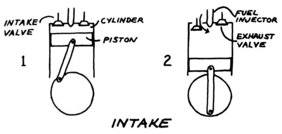

此时气缸的容积非常小，当活塞向下移动时，阀门（称为进气阀）打开，让空气进入。这称为进气冲程（气缸吸入空气）。当活塞接近进气冲程底部时，进气门关闭，活塞向上移动并压缩被关闭的阀门困在气缸中的空气。这就是压缩冲程。“压缩比”是压缩冲程开始时活塞和气缸所围成的体积除以压缩冲程结束时的相同体积。

The volume of the cylinder is very small at that point, and a valve (called the intake valve) opens to let air in as the piston moves down. This is called the intake stroke (the cylinder takes in air). When the piston is near the bottom of the intake stroke, the intake valve closes and the piston moves up and compresses the air that's trapped in the cylinder by the closed valve. This is the compression stroke. The "compression ratio" is the volume bounded by the piston and the cylinder at the beginning of the compression stroke, divided by the same volume at the end of the compression stroke.

当活塞接近压缩冲程末端时，喷油器将柴油喷射到气缸中。燃料蒸发并燃烧，燃烧燃料产生的热量进一步提高压力并向下推动活塞。这就是动力冲程。

When the piston is near the end of the compression stroke, the fuel injector squirts diesel fuel into the cylinder. The fuel evaporates and burns, and the heat generated by the burning fuel raises the pressure even more and pushes the piston down. This is the power stroke.

一旦活塞触底，排气门打开，活塞将燃烧的燃料从气缸中推出到尾管。这就是排气冲程。

Once the piston bottoms out, the exhaust valve opens and the piston pushes the burned fuel out of the cylinder to the tailpipe. This is the exhaust stroke.

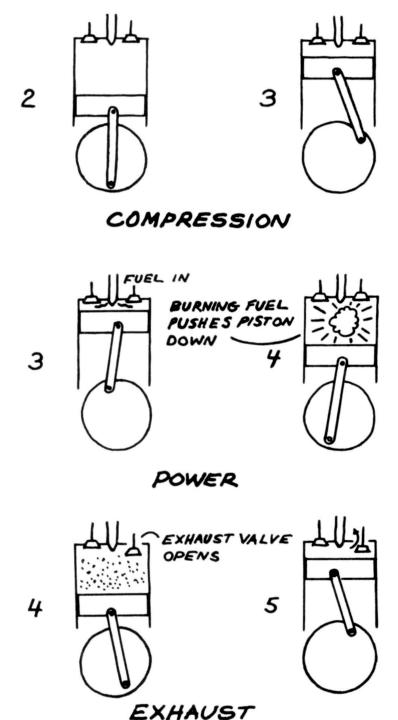

然后进气门打开，循环重复进行。我从九年级时从百科全书中解释的科学报告中记住了这些。

Then the intake valve opens and the cycle repeats itself. That much I remembered from the science report I paraphrased from the encyclopaedia in ninth grade.

快速压缩机将模拟循环的压缩和燃烧部分。

The rapid compression machine would simulate the compression and combustion parts of the cycle.

在使用 A 形框架之前，我在全新的实验室笔记本上画了一个草图，以记录我们如何装配它。如果出现问题，我们可以参考草图来分析发生了什么。如果我们的工作成功，这个草图可能会对后代的 RCM 学生有所帮助。

Before using the A-frame, I made a sketch in my brand-new lab notebook to record how we rigged it. If anything went wrong, we could refer to the sketch to analyze what happened. If our work was successful, the sketch might be helpful for future generations of RCM students.

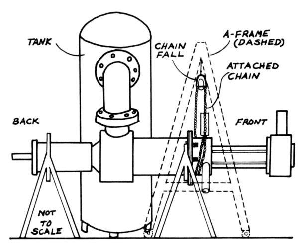

尼克同意我的安排，我们就开始工作了。A 形框架就位，链条坠子缠绕在气缸上，他说：“好的，船长。从我的工具箱里拿出一把扳手，松开螺栓。我会稳定链条坠子。”

Nick agreed with my setup and we went to work. The A-frame in place and the chain fall wrapped around the cylinder, he said, "OK, Cap'n. Go get a wrench outa my tool box and undo the bolts. I'll hold the chain fall steady."

由于用力拉扯和一些体重，螺栓松动了。尼克在最后一根链条松开之前收紧了链条。

The bolts loosened with hard tugs and some body weight. Nick tightened the chain just before the last one loosened.

“前气缸中有一个活塞，我们必须将气缸拉开，”尼克说。“来，用这把螺丝刀启动气缸。”

"There's a piston in the front cylinder that we gotta pull the cylinder offa," Nick said. "Here, use this screwdriver to get the cylinder started."

我将螺丝刀插入两个法兰之间，然后将它们松开。当气缸向前移动时，镀铬轴一次出现约四分之一英寸。尼克和我慢慢地将气缸从机器的其余部分移开。

I wedged the screwdriver between the two flanges and eased them apart. As the cylinder moved forward a chrome shaft appeared about a quarter of an inch at a time. Nick and I slowly worked the cylinder away from the rest of the machine.

尼克在两英尺外说道，“放轻松，船长，我们只剩下几英寸了。我们现在不想弯曲那根轴。如果我必须制作一根新轴，那会减慢速度。”

Two feet out, Nick said, "Easy now, Cap'n, we got just a couple more inches. We don't wanna bend that shaft now. It'd slow things up for me to have to make a new one."

我们轻轻地、慢慢地将气缸从活塞上松开，使轴毫发无伤。“让我们把这个东西搬到工作台上，”他说，然后我们沿着工作台对面的 A 形框架和圆柱体行走。

Gently, slowly we freed the cylinder from the piston, leaving the shaft unscathed. "Let's bring this thing onto the workbench," he said, and we walked the A-frame and the cylinder opposite the bench.

“你握住它，船长，我把她举起来，”尼克说着，将链子的自由端一次拉起一两英尺。几分钟之内，他就将圆筒举到了长凳的高度；然后我们跨坐在带有 A 形框架的长凳上并放下气缸。

"You hold it, Cap'n, while I hoist her up," Nick said, pulling the free end of the chain up a foot or two at a time. Within a few minutes, he had lifted the cylinder to the level of the bench; then we straddled the bench with the A-frame and lowered the cylinder.

“那东西怎么样？” 我指着起重机问道。

"How's that thing work?" I asked Nick, pointing to the hoist.

“这就是滑轮原理，”他说。“这有点像yah里有很多滑轮。我拉动滑轮的一端，我试图举起的东西就变成了fah的一半。亚里士多德不是说过，如果他有足够的滑轮，他就可以移动世界？”

"It's just the pulley principle," he said. "It's sorta like theyah's a lot of pulleys in theyah. I pull on one end of the pulley and the thing I'm trying to lift goes half as fah. Wasn't it Aristotle who said that if he had enough pulleys he could move the world?"

我想知道尼克的事实是否正确。不过，总体想法听起来似乎是合理的。“不过，我认为这一切都是从工业革命开始的。”

I wondered whether Nick had his facts straight. The general idea sounded plausible, though. "I thought that stuff all started with the industrial revolution, though."

“不，船长，这种事情已经存在了一段时间了。你认为他们在中世纪是如何建造所有这些大教堂的？他们肯定没有把所有这些岩石搬到山顶，”他回答道。

"No, Cap'n, this kind of thing's been around for a while. How do you think they built all those cathedrals in the Middle Ages? They sure didn't carry all those rocks to the top," he answered.

他说得有道理。滑轮和杠杆已经存在了四、五千年了。它们和轮子一起，是利用自然法则通过缩短距离来放大力量的第一步。

He had a point. The pulley and the lever had been around for four, maybe five thousand years. They were the first steps, along with the wheel, in using the laws of nature to magnify force by shrinking distance.

“好吧，现在就够了，船长。我的面包卷到了。你想从咖啡店买点什么吗？”

"Well, that's enough for now, Cap'n. Time for my roll. You want anything from the coffee shop?"

“不用了，谢谢，尼克。我想我会留在这里，试着弄清楚这些碎片的用途。”

"No thanks, Nick. I think I'll stay here and try to figure out what these pieces do."

“好吧，”他说。“比如说，佩帕，我曾经教过机械加工课程。如果我们每天花一些时间复习基础知识，可能会帮助你脚踏实地。”

"Okeedokay," he said. "Say, Peppah, I used to teach a machining class. It might help you get your feet on the ground if we spend some time each day going over the basics."

“谢谢。我可能会接受你的建议。” 独行侠有托托；我有尼克。

"Thanks. I might take you up on that." The Lone Ranger had Tonto; I had Nick.

尼克走到外面，隔壁莱特兄弟风洞中传来的噪音听起来就像一个中队的 B-17 轰炸机正前往轰炸杜塞尔多夫。广播里播放着“除了我，不要和其他人一起坐在苹果树下”。我一半期待听到战争债券的广告。

Nick went outside and the noise from the Wright Brothers' wind tunnel next door sounded like a squadron of B-17's on their way to bomb Dusseldorf. The radio played "Don't Sit under the Apple Tree with Anyone Else but Me." I half expected to hear an ad for war bonds.

如果你不知道自己在做什么，首先要做的就是努力让自己看起来知道自己在做什么。这可以为你赢得时间。于是我开始清理牢房。我从水箱中取出泛黄的纸，并用尼克的螺丝刀刮掉旧的胶带。我清除了可用的长凳空间中的所有旧垃圾。然后我把实验室里的物品一一列出来，整齐地放在两个工作台之一上。有些设备在要么重生为丰田汽车，要么回到某处垃圾填埋场的铁矿石中之前，永远不会再有其他用途。其他人可能会适应新的实验；如果可以挽救的话，它们可能会节省数天、数周的时间。

If you don't know what you're doing, the first thing to do is to try to look like you know what you're doing. That buys you time. And so I started cleaning up the cell. I removed the yellowed sheet of paper from the tank and scraped the old masking tape away with Nick's screwdriver. I cleared all the old pieces of junk off the available bench space. Then I made a list of the items in the lab as one by one I put them neatly on one of the two workbenches. Some of the devices would never have another use before they either were reborn as a Toyota or went back to iron ore in a landfill somewhere. Others might be adaptable to the new experiment; salvageable, they might save days, weeks of time.

我发现了一件旧的蓝色实验室夹克，名字贴上写着“Don”。我把它穿上了。在其中一个长凳下，我发现了一堆韦斯特论文的旧笔记。他们杂乱无章，这让我感觉好一点，因为我知道，尽管他表面秩序井然，但他的生活中至少曾经出现过一些混乱。

I found an old blue lab jacket with "Don" on the name patch. I put it on. Under one of the benches I found an old pile of notes from West's thesis. They were disorganized and it made me feel a little better to know that for all his surface order there had been at least some chaos in his life at one time.

所有金属都安装在 6 英寸厚的钢垫上，钢垫上有从一端延伸到另一端的槽。这些槽提供了一个用螺栓固定所有重物的地方。我开始清理插槽中的小金属碎片，但这太难了，而且可能浪费时间，所以我只是掸掉垫子顶部的灰尘。我高中的“车间”老师是一名钢铁工人，如果他还活着的话，他可能会给我一些建议。

All the metal was mounted on a 6-inch-thick steel pad with slots running from one end to the other. The slots furnished a place to bolt down all the heavy stuff. I started to clean the little bits of metal out of the slots, but that was too hard and probably a waste of time so I just dusted off the top of the pad. My high school's "shop" teacher, an iron worker, might have had some tips for me if he were still alive.

五点三十分很快就到了。尼克和我用硼砂洗了手，他摘下棒球帽，露出了一个完全光秃秃的脑袋，除了边缘是灰色的。

Five-thirty came quickly. Nick and I washed our hands with Boraxo and he took off the baseball cap, showing a completely bald head except for the gray around the edges.

“明天见，船长，”他说。“保持新鲜感并准备好学习如何进行机械加工。”

"See you tomorrow, Cap'n," he said. "Be fresh and ready to learn how to machine."

“好的，尼克。祝你玩得愉快。”

"Will do, Nick. Have a good one."

晚上 7:45 游泳之后——这确实让我醒了——我在更衣室里看到了 Frederick Weare，那个没有资助我的碎石工。

7:45 P.M. After my swim-it did wake me up-I saw Frederick Weare, the rock crusher who didn't fund me, in the locker room.

“你找到资金了吗？” 他问。

"Have you found funding yet?" he asked.

“是的，事实上。我正在斯隆汽车实验室研究快速压缩机。”

"Yes, as a matter of fact. I'm working on the Rapid Compression Machine in the Sloan Auto Lab."

“对你有好处，”他说。“你们的调查范围到底是什么？”

"Good for you," he said. "What exactly is the scope of your investigation?"

为了让事情发挥作用并离开这里。“我将研究涡流速率对柴油燃烧点火延迟的影响，”我说。

To get the thing to work and to get out of here. "I'll be looking at the effect of swirl rates on ignition delay in diesel combustion," I said.

“嗯嗯。”他再次点头。他没有再问有关柴油燃烧的问题，因为这超出了他的专业范围。“你会使用什么样的仪器？”

"Um hmmm," he nodded again. He didn't ask any more about diesel combustion because that was outside his realm of expertise. "What kind of instrumentation will you be using?"

“我还不太清楚——瞧，这是我第一天，我只是想找个方向，”我回答道。

"I don't know exactly yet-see, this was my first day and I'm just trying to get oriented," I answered.

“嗯，听起来很有趣。祝你好运。”

"Well, it sounds like a lot of fun. Good luck with it."

谢谢，弗雷德。也许有一天我们会共同撰写一篇论文。

Thanks, Fred. Maybe we'll co-author a paper some day.

8:15 PM 未能从历史中汲取教训的人注定会重蹈覆辙。过去的实验论文位于巴顿工程图书馆八楼。化学、电气、土木、核、机械工程。一排排黑色装订的打字纸页，每页都有前作者、顾问、研究生系主任的三个签名。侧面用瘦小的白色大写字母写着作者的名字，以及完成年份，最早可以追溯到 20 世纪 40 年代。如果再往前追溯，你就必须去看缩微胶片。

8:15 P.M. He who fails to learn from history is doomed to repeat it. The theses of experiments past are on the eighth floor of the Barton Engineering Library. Chemical, electrical, civil, nuclear, mechanical engineering. Rows upon rows of black-bound typewritten pages, each with three signatures on the front-author, adviser, graduate department chairman. The name of the author is written on the side in skinny white capital letters, together with the year of completion, as far back as the 1940s. Any further back than that and you have to go to microfiche.

我从韦斯特开始，科学博士。'71。有一些发出黄色火焰的彩色图片。科学博士 是科学博士，这比博士更有意义。因为汽车机械师与科学的距离比与哲学的距离要近得多。只有麻省理工学院、斯坦福大学、加州理工学院和其他一些精选学校提供科学博士学位的选择。而不是博士学位。文凭上。它使超级精英能够相互认出，而无需弯腰询问他们的资历是从哪里获得的。

I started with West, Sc.D. '71. There were some color pictures of glowing yellow flames. An Sc.D. is a doctor of science, which makes more sense than a Ph.D. since auto mechanics is a lot closer to science than it is to philosophy. Only MIT, Stanford, Cal Tech, and a few other choice schools offer the option of Sc.D. instead of Ph.D. on the diploma. It enables the hyperelite to recognize each other without stooping to ask where they earned their credentials.

我查看了韦斯特论文后面的参考文献列表。他提到了 68 年的 Pyra，他拥有布拉格大学的学士学位。Pyra 没有任何图片，只有图表。我把它们都放在我的堆栈中。Pyra 提到了 Nayak，'63-BS，开罗大学。Nayak 也有很多图表，他提到了 Rathle，'5 9。Rathle 于 1957 年从埃及亚历山大大学获得了学士学位。Rathle 建造了 RCM。我和我的设备都二十五岁了。

I looked in the list of references in the back of West's thesis. He referred to Pyra, '68, whose B.S. was from the University of Prague. Pyra didn't have any pictures, just graphs. I put them both in my stack. Pyra referred to Nayak, '63-B.S., University of Cairo. Nayak had lots of graphs, too, and he referred to Rathle, '5 9. Rathle had received his B.S. from the University of Alexandria, Egypt, in 1957. Rathle had built the RCM. My apparatus and I were both twenty-five years old.

拉思尔的图表让我眼前一亮。该机器有三个室。发生燃烧的前气缸是尼克和我当天早些时候拆下的。前部的后部有“止回爪”，当轴到达冲程末端时，止回爪卡住轴，防止其向后弹跳或被爆炸柴油的压力向后推。中间的气缸装有压缩空气和一个尺寸是前活塞四倍的活塞。更大的面积使整个轴能够向前移动，即使燃烧室的压力远高于油箱中的压力。

Rathle's diagrams made the scales drop from my eyes. The machine had three chambers. The front cylinder, where combustion took place, was what Nick and I had removed earlier in the day. The back part of the front part had "nonreturn pawls," which caught the shaft as it went to the end of the stroke and kept it from bouncing backward or being pushed backward by the pressure of the exploding diesel fuel. The middle cylinder had compressed air and a piston four times the size of the front piston. The bigger area enabled the whole shaft to move forward, even when the combustion chamber's pressure was much higher than the pressure in the tank.

后缸内装有各种尺寸的环，并充满传动液。后缸轴上的活塞会减慢整个轴的速度，使压缩冲程类似于真实发动机中的压缩冲程，其中活塞连接到旋转曲轴。

The back cylinder had various-size rings in it and was filled with transmission fluid. A piston on the shaft in the back cylinder would slow down the whole shaft to make the compression stroke similar to that in a real engine, where the piston is attached to a rotating crankshaft.

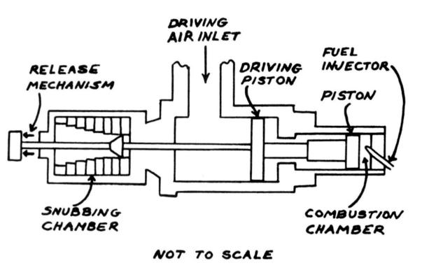

从 Rathle 开始，参考文献就出现在期刊中——Taylor，1948；塞尔登，1937；罗斯罗克，1932；摩尔，1922；福尔克，1906 年。

From Rathle back the references were in journals-Taylor, 1948; Selden, 1937; Rothrock, 1932; Moore, 1922; Falk, 1906.

福克的机器是一个充满氢气的垂直管。他的轴顶部有一个铅锤，活塞上有绳索活塞环来密封活塞和气缸之间的间隙。他放下重物并测量气体燃烧的温度。第一个版本很简单，几乎微不足道，但本质上与我的大块灰色金属相同。

Falk's machine was a vertical tube filled with hydrogen. His shaft had a lead weight on top, and the piston had rope piston rings to seal the gap between the piston and cylinder. He dropped the weight and measured the temperature at which the gas combusted. That first version was simple, almost trivial, but essentially the same as my large gray mass of metal.

法尔克提到勒夏特列，正如勒夏特列原理（1888）中所说：当外力施加到平衡状态的系统时，系统会进行调整，以尽量减少所施加力的影响。”顺其自然。

Falk referred to LeChatelier, as in Le Chatelier's Principle (1888) : When an external force is applied to a system at equilibrium, the system adjusts so as to minimize the effect of the applied force." Go with the flow.

我在大英百科全书中查找了迪塞尔。鲁道夫·迪塞尔（Rudolph Diesel，生于 1858 年，卒于 1913 年），德国热能工程师，也是一位杰出的艺术鉴赏家、语言学家和社会理论家。在奥格斯堡的技术学校期间，他观看了中国古代火棍的演示。火棒的历史可以追溯到公元前 1000 年或更早，就像安装在自行车车架上的自行车打气筒一样。你将一片干树叶或一块干燥的易燃木头放在一端，将其关闭，对泵进行一次良好的快速压缩，然后启动，点火。从这次演示中产生了他的发动机的想法。

I looked up Diesel in Encyclopaedia Britannica. Rudolph Diesel (born 1858, died 1913), German thermal engineer, was also a distinguished connoisseur of the arts, a linguist, and a social theorist. While at the technical school in Augsburg, he saw a demonstration of the ancient Chinese fire stick. The fire stick, dating to 1000 B.C. or earlier, is like the bicycle pumps that fit on the frame of the bicycle. You put a dry leaf or a dry tindery piece of wood in one end, close it off, give the pump one good rapid compression, and pow, fire. From that demonstration came the idea for his engine.

我觉得我和一群很好的人在一起，继承着传统、遗产。

I felt I was in good company, carrying on a tradition, a legacy.

迪塞尔开发了他的发动机，积累了巨大的财富，但投资却很糟糕，但由于未知的原因，他在前往伦敦的途中从德累斯顿号邮船的甲板上“显然坠落”了。

Diesel developed his engine, amassed great wealth, invested poorly, and for reasons unknown "apparently fell" from the deck of the mail steamer Dresden en route to London.

周三

Wednesday

“这个嘿哟是千分尺，”尼克说。“你拿这个来测量某个东西有多大，以千分之一英寸为单位。真正奇特的尺寸会下降到万分之一，但我们只会做千分之一。”

"This heeyuh's a micrometer," Nick said. "You take this and you measure how big something is, in thousandths of inches. The real fancy ones go down to ten-thousandths, but we'll just do the thousandths."

千分之一英寸对我来说似乎小得难以理解——怎么可能精确地测量任何东西呢？如此规模的事情怎么可能重要呢？

A thousandth of an inch seemed incomprehensibly small to me-how could anything be measured that precisely? How could anything matter on that scale?

尼克继续说道：“你像这样握住千分尺，看，然后将两个销钉彼此分开地放在工件上。” 工件是安装在车床上的金属棒。“你想让千分尺的两端从工件上滑落，然后读取它。这会告诉你还需要脱掉多少千分之一。这根杆上有一点生锈，我们可以采取这一点要么把可乐倒在上面，要么把它关小。”

Nick continued, "You hold the micrometer like this, see, and you put the two pins just apart from each other on the workpiece." The workpiece was a bar of metal mounted in the lathe. "You want to make the two ends of the micrometer just slip off the workpiece and then you read it. That'll tell you how many thousandths you still need to take off. There's a little rust on this bar, and we can take that off by either pouring Coke over it or turning it down."

我想知道机械师从一块金属上刮下皮肤的表情与作为一个人被拒绝之间是否有任何联系。

I wondered whether there were any connection between the machinists' expression for scraping the skin off a piece of metal and being turned down as a person.

“首先我们必须将工具放入工具架中，”尼克继续说道。“这就是刀刃，”他一边说，一边握住那块一英寸长的金属片，指着锋利的一面。“我们将把它用螺栓固定到机器上，然后通过转动这里的交叉进给手轮将其带到工件上。”

"First we gotta put the tool in the tool holder," Nick continued. "This here's the cutting edge," he said, holding the inch-long piece of metal and pointing out the sharp side. "We're going to bolt it into the machine and then bring it just up to the workpiece by turning the cross-feed handwheel here."

手轮上有刻度，因此手轮旋转一圈，可使安装有切削刀具的金属块向工件移动十分之一英寸。旋钮上的刻度盘外侧有 100 个哈希标记。划分十分之一英寸的一百个哈希标记允许您将切削工具移动千分之一英寸。就像千分尺一样，该装置可以放大空间。

The handwheel had gradations in it so that one revolution of the handwheel made the block of metal to which the cutting tool was attached move a tenth of an inch toward the workpiece. The dial on the knob had 100 hash marks around the outside. The hundred hash marks dividing up a tenth of an inch allow you to move the cutting tool a thousandth of an inch. Like the micrometer, the device magnifies space.

尼克将刀具推向工件，然后将其向前移动千分之五。该工具在锈迹上切开了一点条子，露出了下面纯净、干净的钢材。“现在，船长，慢慢地转动这个曲柄，你就会把整根杆子减掉千分之五。不过，我们先在上面涂一点切削油。”

Nick advanced the tool to the workpiece and then moved it forward five thousandths. The tool cut a little sliver through the rust, showing the pure, clean steel underneath. "Now, Cap'n, turn this crank nice and slow and you'll take five thousandths off the whole rod. Let's put a little cutting oil on there first, though."

他从油罐里滴了几滴，看起来就像工程师用来润滑火车的那种。当工具接触时，油冒烟，我慢慢转动曲柄，当我从轴的长度上去除千分之一时，条子形成了连续的钢丝。

He put a few drops from the oil can that looked like the kind engineers use to lubricate their trains. The oil smoked when the tool made contact, and I turned the crank slowly and the sliver made a continuous thread of steel as I removed the thousandths from the length of the shaft.

“很好，船长。现在把工具带回来，你就可以多花千分之几来练习了。” 我又去掉了千分之十，在去掉千分之十五的地方，杆的长度明显变小了。

"Very good, Cap'n. Now bring the tool back and you can take some more thousandths off for practice." I took ten more thousandths off and the rod was noticeably smaller on the length where I removed the fifteen thousandths.

“今天的学习应该足够了，船长。我带了这本书给你看，”尼克说着，递给我一本他在第一堂机械车间课上使用过的涂有油脂的手册——实用手册。加工。

"That oughta be enough school for today, Cap'n. I brought in this book for you to take a look at," Nick said, handing me the grease-marked manual that he'd used in his first machine shop class-Practical Machining.

封面插图展示了十六世纪的工人正在操作脚踏车床。首先是砖块，然后是滑轮、火棒，现在简单的车床想法已经存在很长时间了。

The cover illustration showed workers in the sixteenth century operating a foot-powered lathe. First the brick, then the pulley, the fire stick, now the lathe-simple ideas have been around for a very long time.

我走回牢房，在玛丽走进商店的路上遇见了她。她穿着一件实验夹克，上面写着她的名字，名字上方写着“Dynatech”。

I walked back to my cell and met Mary on her way into the shop. She wore a lab jacket with her name written on it, and above her name was written "Dynatech."

“嗨，唐，”她指着我的实验室夹克说道。

"Hi, Don," she said, referring to my lab jacket.

“嗨，玛丽。是什么让你来到这些岗位的？我以为你还是一名助教呢。”

"Hi, Mary. What brings you to these parts? I thought you were still a teaching assistant."

“我和 West 签订了 RA，就像你一样，”她说。“我正在实验室另一端与保罗·卡恩一起研究卡特彼勒发动机。” 她看着尼克借给我的书，说道：“开始做生意？”

"I got an R.A. with West, just like you," she said. "I'm working with Paul Kahn on the Caterpillar engine at the other end of the lab." She looked at the book Nick lent me and said, "Taking up a trade?"

“这么说吧，这将是我的经济衰退保险。”

"Let's just say it'll be my recession insurance."

“如果你想要经济衰退保险，你应该成为一名水管工。机械师将是第一个被解雇的。”

"If you want recession insurance you ought to become a plumber. Machinists will be the first to get laid off."

“是啊，好吧，我越多才多艺越好。你想看看我的牢房吗？”

"Yeah, well, the more versatile I can be the better. Do you want to take a look at my cell?"

“当然，”她说。

"Sure," she said.

我打开门。工作台上的牛皮纸以及摆放整齐的设备和工具给她留下了深刻的印象。“它看起来非常专业，”她说。“墙上的裂缝是什么？” 她问。

I opened the doors. She was impressed by the brown paper on the workbenches and the neatly laid out equipment and tools. "It looks very professional," she said. "What's that crack up at the top of the wall there?" she asked.

“过去每次测试时，机器都会把建筑物的一部分带走。释放的力量就像小炮一样。”我回答道。

"The machine has taken part of the building with it every time they've done a test in the past. The forces released are like those from a small cannon," I answered.

“哇哦。小心点。我希望你在这里的时候不会发生任何爆炸。”

"Whoa. Be careful. I hope nothing blows up while you're in here."

我还没有想到危险。然后我想起了韦斯特关于物理学家和激光的故事。马特·阿姆斯特朗告诉我，麻省理工学院的正式职业安全相当宽松，因为研究生应该是专业人士，而专业人士会照顾好自己。

The danger hadn't yet occurred to me. Then I remembered West's story about the physicist and the laser. And Matt Armstrong had told me that formal occupational safety at MIT is fairly lax because graduate students are supposed to be professionals, and professionals take care of themselves.

“我会小心的。我们可以看一下你的牢房吗？”

"I'll be careful. Can we take a look at your cell?"

“当然，”当我们走向实验室的北端时，她回答道。

"Sure," she answered, as we walked to the north end of the lab.

我看到其他测试室门上的标语：“定容燃烧弹：赞助商：能源部”；“方活塞透明发动机：赞助商：工业联合体”；“用于研究活塞环运动的透明气缸：赞助商：通用汽车公司。” 我问玛丽她是否知道这些项目是如何获得资金的。

I read the signs on the doors of the other test cells: "Constant Volume Combustion Bomb: Sponsor: Department of Energy"; "Square Piston Clear Engine: Sponsor: Industrial Consortium"; "Clear Cylinder for Study of Piston Ring Motion: Sponsor: General Motors." I asked Mary whether she knew how these projects got funded.

“有多种途径。其中一些公司有研究预算，用于大学。汽车行业研究部门的一半人都拥有这里的学位，他们在发放资助时会想起他们的伙伴。一些赞助商期望真正的结果，直接应用于发动机的东西，但大多数情况下他们追求的是概念的进步和对过程的理解。他们在教授和学生基于研究撰写的论文中得到了这一点。另外，他们得到了很好的结果-训练有素的研究人员可以立即开始为通用汽车、克莱斯勒或福特开发产品。我们来了。”

"There're several avenues. Some of these companies have research budgets that they spend on universities. Half the people in the automotive industry's research departments have degrees from here, and they remember their buddies when they give out the grants. Some of the sponsors expect real results, things that will directly apply to engines, but mostly they're after advances in concepts and understanding of the processes. They get that in the papers the professors and students write that are based on the research. Plus, they get well-trained researchers who can hit the ground running developing products for GM, Chrysler, or Ford. Here we are."

她打开牢房的门，里面有一个蓝色的、新漆的发动机，有大约二十根电线连接到角落里一个看起来像电脑的东西。

She opened the door to her cell, where there was a blue, newly painted engine with about twenty wires connecting it to a computery looking thing in the corner.

“那是什么？” 我问。

"What's that?" I asked.

“这是实验室数据采集系统。安装在发动机上的传感器将数据发送到这里的小计算机。然后它将数据文件下载到楼上的大型计算机进行分析。”

"It's the lab data acquisition system. The sensors mounted on the engine send their data to the little computer here. Then it downloads the data files to the mainframe computer upstairs for analysis."

够简单的。“那么到目前为止进展如何？” 我问。

Simple enough. "So how's it going so far?" I asked.

“很好，”她平静地说。“唯一的问题是，我的项目合作伙伴是佐治亚理工学院的一个真正的傻瓜。我不知道他是如何被录取的。”

"Pretty good," she said quietly. "The only problem is that my partner on the project is a real dork from Georgia Tech. I don't know how he got accepted."

也许他和韦斯特谈论了自行车。

Maybe he talked bicycles with West.

“好吧，我希望一切顺利，”我说。“我必须回去工作。现在每一分钟的进步都意味着我会更快地完成工作，并能够继续我的生活。”

"Well, I hope everything works out all right," I said. "I've got to go back to work. Every minute of progress now means I'll finish that much sooner and be able to get on with my life."

我看了看机器前面的镀铬轴，尼克和我在前一天拆下气缸时揭开了这个轴。它周围大约三分之一处有一条裂缝，就在止回爪卡住它的肩部附近。压迫的力量已经造成了伤害。我从轴的其余部分拧下镀铬部分，并将棒球棒大小的轴带到尼克在一块金属上钻孔的地方。

I looked at the chrome-plated shaft on the front of the machine, the shaft Nick and I'd unveiled when we removed the cylinder the day before. It had a crack about one-third of the way around it, right near the shoulder where the nonreturn pawls caught it. The force of the compressions had taken their toll. I unscrewed the chrome section from the rest of the shaft and carried the baseball-bat-size shaft to where Nick was drilling a hole in a piece of metal.

“有问题，尼克。轴上有裂缝。我们有什么办法可以修复它吗？我不希望一年后当我快要完成我的实验时这东西会折断。”我说。

"Problem, Nick. The shaft's got a crack in it. Is there any way we can fix it? I don't want the thing to break off a year from now when I'm almost ready to finish my experiments," I said.

“我们可以不理会它——它可能会保持笔直直到断裂——或者我可以在整个轴周围焊接一个珠子。这会让它更坚固，但它可能会使轴稍微弯曲。这取决于你”。

"We could leave it alone-it'll probably stay straight until it breaks-or I can weld a bead around the whole shaft. That'll make it stronger, but it'll probably bend the shaft a little. It's up to you."

“如果轴弯曲了，我们能把它弯曲回来吗？”

"If the shaft bends, can we bend it back?"

“我们可以尝试，”他说。

"We can try," he said.

“好吧。我们去焊接吧。”

"OK. Let's go for the weld."

我们去了焊接区域，尼克戴上了他的小焊接帽和皮革，这让他看起来像西班牙宗教裁判所中的酷刑者。他递给我一套皮手套、一顶帽子和一顶玻璃纤维焊接头盔，头盔上有经过处理的玻璃缝，可以通过它观察焊缝。玻璃处理可以让您看到焊缝，但看不到其他东西。

We went to the welding area and Nick put on his little welding cap and the leathers that made him look like a torturer in the Spanish Inquisition. He handed me a set of leather gloves, a cap, and a fiberglass welding helmet with a treated glass slit through which to look at the weld. The glass treatment allows you to see the weld but not much else.

“好的，船长。你握住它并慢慢转动它，然后我会焊接它。如果你握住末端，你就会离得足够远，任何金属都不会撞击，所以你不需要皮革。 ”

"OK, Cap'n. You hold it and turn it slowly, and I'll weld it. If you hold the end you'll be fah enough away an none of that metal will hit, so you won't need leathers."

我戴上头盔，尼克也戴上。焊缝的明亮闪光接触到肩部的金属，我慢慢地转动轴。尼克花了大约两分钟的时间将其周围焊接完整，将暂时熔化的金属像蛋糕糖霜一样分层。

I put on my helmet, as did Nick. The bright flash of the weld contacted the metal at the shoulder and I slowly turned the shaft. It took about two minutes for Nick to weld all the way around it, layering the temporarily molten metal like cake frosting.

“好了。应该可以了，”他说。“现在，在你用它做任何其他事情之前，先把它放进那边的水桶里。”

"There. That should do it," he said. "Now before you do anything else with it, put it in that bucket of water over there."

我将焊接端放入桶中，它像水槽中的热煎锅一样闪动水。

I put the welded end in the bucket, and it flashed the water like a hot frying pan in a sink.

“把它放在那里一段时间。那家伙很性感，”尼克说。

"Keep it in there for a while. That guy's hot all right," Nick said.

蒸汽消失后，我们将轴放入车床上。尼克设置了一个千分表，一个小圆形仪表，一侧有一根销钉，仪表上有一根指针。如果将销钉推入，针会四处移动并告诉您销钉被推入的距离。尼克将销钉抵在轴的焊接端，就像他将切割工具抵在钢片上一样。

After the steaming died down we put the shaft in the lathe. Nick set up a dial indicator, a little round gauge with a pin coming out of one side and a needle on the gauge. If you push the pin in, the needle moves around and tells you how far the pin is pushed in. Nick put the pin against the welded end of the shaft just as he'd put the cutting tool against the piece of steel.

“是时候评估损失了，船长，”他边说边转动轴。当他转动轴时，指针一路上升，到表盘上的千分之十五，然后回到零，然后又上升到千分之十五，又回到零。“还不错，”他说。“现在去哈玛。”

"Time to assess the damage, Cap'n," he said, as he turned the shaft around. The needle went way up, to fifteen thousandths on the dial, then back to zero, and then up to fifteen thousandths and back to zero as he turned the shaft around. "Not too bad," he said. "Now for the hammah."

“你会怎样做？” 我问。

"What are you going to do?" I asked.

“轻拍一下，让它再次变直。”

"Give it a tap to make it straight again."

他转动轴，使最高点位于千分表销处，将千分表移开，然后用塑料头木槌快速、尖锐地敲击轴的末端。他再次设置了指示器，最高点下降到千分之四半。

He turned the shaft so the high spot was at the dial indicator pin, moved the dial indicator away, and gave the end of the shaft a quick, sharp tap with the plastic-headed mallet. He set up the indicator again and the high spot was down to four and a half thousandths.

“我想我们最好趁我们领先的时候放弃，船长，”他说。“这家伙够正直，还能再坚持二十年。”

"I think we bettah quit while we're ahead, Cap'n," he said. "This guy's straight enough and he'll last another twenty years."

“好的，尼克。谢谢。”

"OK, Nick. Thanks."

那天晚上，外面的温度低于零，钥匙无法插入我的氪石自行车锁。锁上的金属已经收缩了——收缩幅度不大，可能是千分之一英寸或两英寸，但足以阻止那把又大又热的钥匙插入。

That night the temperature outside was below zero and the key wouldn't go into my Kryptonite bicycle lock. The metal in the lock had shrunk-not much, maybe a thousandth of an inch or two, but enough to prevent the big, warm key from fitting.

在咖啡店里，我要了一杯热水、一个塑料袋和一根橡皮筋。

At the coffee shop I asked for a cup of hot water, a plastic bag, and a rubber band.

我把塑料袋包在锁上，用橡皮筋固定，然后慢慢地将热水倒在塑料袋上。然后我迅速取下塑料，将钥匙插进锁，打开自行车，然后骑回家睡觉。

I wrapped the plastic bag around the lock, secured it with the rubber band, and slowly poured the hot water over the plastic. Then I quickly removed the plastic, put the key into the lock, unlocked the bike, and rode home to bed.

麻省理工学院的座右铭是“Mens et Manus”——“思想和手”。

The MIT motto is "Mens et Manus"-"Mind and Hand."

# 章节

# C H A P T E R

# 8

# 8

# 监工们

# The Taskmasters

法老吩咐监工说，你们不可再给百姓干草做砖。……让人们承担更多的工作，让他们在其中劳作；让他们不要重视虚言......

And Pharoah commanded the taskmasters, saying ye shall no more give the people straw to make brick. ... Let there more work be laid upon the men, that they may labor therein; and let them not regard vain words....

出埃及记 5:6-9

EXODUS 5:6-9

日程：

Schedule:

82 年春季：2.651 内燃机（Heywood）

Spring '82: 2.651 The Internal Combustion Engine (Heywood)

2.999 独立研究（格林）

2.999 Independent Study (Greene)

2.996 论文

2.996 Thesis

1982 年 2 月 15 日

February 15, 1982

能源实验室会议室位于阿默斯特街四楼，斯隆学院对面。当研究赞助商吃着他们选择的麻省理工学院餐饮服务可以召集的最好的糕点时，变阻器控制的灯处于全亮度。甚至咖啡也很好吃。

The Energy Laboratory conference room is inside the fourth floor on Amherst Street across from the Sloan School. The rheostatcontrolled lights were at full brightness while the Sponsors of the Research ate their choice of the best pastries MIT's catering service could muster. Even the coffee was good.

这是赞助商抚摸的时间。菲利普·休斯 (Philip Hughes) 是澳大利亚人，曾任卡特彼勒 (Caterpillar) 发动机研究总监。Sharma 来自印度，在 20 世纪 60 年代初发表了一篇关于柴油燃烧理论的探路论文，并领导了约翰迪尔的发动机研究。艾伯特·李 (Albert Lee) 在康明斯发动机公司一步步晋升——他是我之前最后一个在 RCM 工作的人。今年我的同事之一是让·奎斯图瓦 (Jean Questois)，他是雷诺巴黎办事处的一颗冉冉升起的新星。他们是最字面意义上的工程师。

It was sponsor-stroking time. Philip Hughes, an Australian, was director of engine research for Caterpillar. Sharma, originally from India, had published a path-finding paper on the theory of diesel combustion in the early 1960s and headed up engine research at John Deere. Albert Lee was working his way up the ladder at Cummins Engine Company-he was the last person to work on the RCM before me. And one of my office mates for the year was Jean Questois, a rising star from the Paris office of Renault. They were engineers in the most literal sense of the word.

这里没有细条纹；棕色和浅蓝色是首选的服装颜色。

No pinstripes here; brown and light blue were the clothing colors of choice.

斯隆团队有更多成员。船长是斯隆实验室主任、剑桥大学荣誉学位获得者约翰·B·海伍德教授。韦斯特是一名中尉；另一个是Chet Yeung。切特是一位新任助理教授，他的博士学位。来自麻省理工学院航空工程系，学士学位来自世界上唯一比麻省理工学院-加州理工学院更好的学院。

Team Sloan had more members. The captain was Professor John B. Heywood, director of the Sloan Lab, graduate of University of Cambridge, recipient of honorary degrees. West was one lieutenant; the other was Chet Yeung. Chet was a new assistant professor, whose Ph.D. was from the Aeronautical Engineering department at MIT and whose bachelor's degree was from the one institute in the world that is better than MIT-Cal Tech.

我是一个暴徒，正如史努比驾驶索普威思骆驼飞越他们时所说的那样，第一次世界大战的战壕步兵。我的新实验室伙伴斯科特·罗杰斯也是如此。斯科特负责大部分计算机工作，我负责大部分实验工作。第三个坏蛋是本·拉多夫斯基（Ben Radovsky），他在隔壁的牢房里从事方形活塞发动机的工作。我们的使命——我们别无选择，只能接受——是让那些穿浅蓝色和棕色衣服的人相信他们的钱花得值。

I was a blighter, as Snoopy called the World War I trench footsoldiers as he flew over them in his Sopwith Camel. So was Scott Rogers, my new lab partner. Scott would do the bulk of the computer work, I the bulk of the experimental work. The third blighter was Ben Radovsky, who worked on the square piston engine in the cell next door. Our mission-and we had no choice but to accept it-was to convince the men in light blue and brown that their money was well spent.

海伍德教授于 9:00 准时召开了会议。“我要感谢你们今天来到这里。我们的学生在过去的一个半月里一直非常努力，我想你们会对他们迄今为止所取得的进步感到满意。” 他的英国口音让他听起来比他实际上更聪明。我想像他一样，掌控局势。

Professor Heywood brought the meeting to order promptly at 9:00. "I'd like to thank you all for coming here today. Our students have been working very hard during the past month and a half, and I think you'll be pleased with the progress that they've made to date." His British accent made him sound even smarter than he was. I wanted to be like him, to command the situation.

“我们将以 Pepper White 的演讲开始会议，介绍快速压缩机实验计划的机械方面的进展，”他说。

"We'll start the meeting with a presentation by Pepper White, on the progress on the mechanical aspects of the rapid compression machine experimental programme," he said.

我的膝盖在颤抖。在经历了几次这样的会议之后，我想，任何工作面试都应该是小菜一碟。

My knees were shaking. After I've been through a few meetings like this, I thought, any job interview should be a piece of cake.

海伍德教授继续平稳地说：“然后斯科特·罗杰斯和切特·杨将讨论我们将要开发的柴油燃烧计算机模型的一些想法。午餐后，我们将听取本·拉多夫斯基的发言，然后参观实验室。在 Pepper 之前不过，首先，我想提醒大家，我们希望扩大联盟计划以包括更多赞助商，如果您知道其他发动机公司或石油公司的同事可能有兴趣参与该计划，我们'我非常感谢您让我们与他们取得联系。”

Professor Heywood continued smoothly, "Then Scott Rogers and Chet Yeung will discuss some thoughts on the computer model of diesel combustion we'll be developing. After lunch, we'll hear from Ben Radovsky and then take a tour of the lab. Before Pepper starts, though, I'd like to remind you all that we hope to expand the consortium programme to include more sponsors, and if you know of colleagues at other engine companies or oil companies who might be interested in participating in the programme, we'd be most appreciative of your putting us into contact with them."

我把一叠透明胶片和纸板框架（就像吉夫托普洛斯使用的那种）放在高架投影仪旁边，并在他完成后打开投影仪。我站在屏幕旁边，直到提示出现。

I put the stack of transparencies with the cardboard frames like the ones Gyftopoulos used next to the overhead projector and turned the projector on while he finished. I stood next to the screen until my cue came.

本把灯调暗。会议桌周围的所有人的脸都被屏幕的光照亮了。在房间黑暗的背景下，只有面孔显露出来，就像在剧院里一样。眼睛是专注的、聪明的、善良的、正派的，因为工程中没有谎言的余地。在科学领域，你可以撒谎和捏造数据，因为你不需要让任何事情发挥作用。在工程方面，产品是您诚实的证明。

Ben dimmed the lights. All the faces around the conference table were lit up by the light of the screen; only the faces showed against the darkened background of the room, as in a theater. The eyes were focused, intelligent, good, and decent, since there is no room for lies in engineering. In science you can lie and fudge the data because you don't have to make anything work. In engineering the product is the proof of your honesty.

第一张幻灯片。“我想谈谈我们的总体目标、具体的短期目标、过去几周我们完成的一些事情以及未来几个月的时间表。”

First slide. "I'd like to talk about our general objectives, our specific short-term objectives, some of the things we've accomplished in the past several weeks, and the schedule for the coming months."

当观众微笑并专心聆听时，我的膝盖颤抖开始减轻。我使用了正确的行话。

My knees started to shake less as the audience smiled and listened attentively. I was using the right lingo.

“首先是总体目标：我们想让机器启动并运行，并确定我们可以进行实验的范围。这意味着我们需要确定我们可以从机器获得的最大压力和温度，以及如何无论有无燃烧，我们都可以获得高涡流率。”

"First the general objective: We'd like to get the machine up and running and determine the range over which we can conduct our experiments. That means we need to determine the maximum pressure and temperature we can obtain from the machine, and also how high a swirl rate we can obtain, with and without combustion."

下一张机器幻灯片图。正如您所看到的，该机器具有三个室。前面当然是燃烧室；后面是驱动气室，连接压缩空气储罐；轴的更深处是带压作业室，里面充满了传动液和不同内径的环。带压作业室中的活塞在压缩冲程期间减慢轴的运动。通过改变环的顺序，我们可以使轴和活塞的运动模拟实际柴油机的运动。当轴完全向前移动时，止回爪会将轴锁定到位。因此，我们有能力观察在恒定体积下发生的燃烧。”明亮的面孔仍然微笑着。在过去的六周里，我学到了很多单词。

Next slide-diagram of machine. As you can see, the machine has three chambers. The front is, of course, the combustion chamber; behind it is the driving air chamber, connected to a compressed air storage tank; farther back on the shaft is the snubbing chamber, filled with transmission fluid and rings of varying inner diameters. The piston in the snubbing chamber slows the shaft motion down during the compression stroke. By varying the order of the rings, we can make the motion of the shaft and piston simulate that of an actual diesel. The nonreturn pawls will lock the shaft in place when it has moved fully forward. We thus have the ability to look at combustion occurring at constant volume." The bright faces were still smiling. I'd learned a lot of words in the past six weeks.

我接着告诉他们如何拆开机器并将其重新组装起来，如何与尼克一起固定轴，如何测量和绘制带有新的青铜聚四氟乙烯一体式活塞环的新活塞，如何对其进行加工并感觉它是否适合机器。轴。关于第一次整机测试不成功。

I went on to tell them about taking the machine apart and putting it back together, about fixing the shaft with Nick, about measuring and drawing a new piston with new bronze-Teflon onepiece piston rings, about having it machined and feeling it fit into the shaft. About the first unsuccessful test of the whole machine.

最后，全场响起热烈的掌声，在走向咖啡桌和丹麦餐桌的路上，韦斯特说：“头等舱。” 也许我毕竟不是一个傻瓜，我想。也许我只是在第一学期不了解这个制度，这个制度鼓励你放弃任何低于平均水平的课程。

At the end there was a warm round of applause, and on the way to the coffee and Danish table, West said, "First class." Maybe I'm not such a dummy after all, I thought. Maybe I just didn't know the system during the first term, the system that encourages dropping any course in which you're below average.

午休前，夏尔马要求我们提供每月进度报告。哦，不，还有更多的工作，我想。海伍德教授显然也是如此。

Before the lunch break, Sharma asked for monthly progress reports from us. Oh no, more work, I thought. Evidently so did Professor Heywood.

“他们是聪明的年轻人，但对他们的时间有很多要求，这可能会阻碍他们的研究进展，”他说。

"They're bright young people, but there are many demands on their time and it might impede their progress on the research," he said.

“你的意思是告诉我们，你为我们培养的人将无法每月写一篇简短的段落来说明他们所取得的成就以及他们的前进方向吗？” 夏尔马反驳道。

"Do you mean to tell us that the people you're producing for us won't be able to write a brief paragraph once a month saying what they've accomplished and where they're headed?" Sharma retorted.

海伍德教授毫不退缩地进行了回避。他仍然掌控一切，是典型的资助者。“也许报告可以每两个月准备一次，”他说。他知道他必须审阅它们，他的秘书必须打印它们，他可能必须与整个小组会面只是为了讨论这个主题。这很容易消磨一个上午的时间，而他本来应该把时间花在写书上。

Professor Heywood hedged without flinching. He was still in control, the quintessential grantsman. "Perhaps the reports could be prepared every two months," he said. He knew that he would have to review them, that his secretary would have to type them, that he might have to meet with the whole group just to discuss that one subject. It could easily kill a morning that would be better spent writing his book.

“对我来说每两个月一次就可以了，”夏尔马说，其他人也同意。

"Every two months would be fine with me," Sharma said, and the others agreed.

2月17日

February 17

艾伦·格林教授的办公室位于 7 号楼的二楼，俯瞰马萨诸塞大街和街对面的学生中心。在十月初他的能源工程讲座后我们进行了交谈，他同意在一月份收我作为一名独立学习的学生。我记得《论文追逐》中的一件事，当时哈特很荣幸地被金菲尔德邀请帮助他准备一篇学术文章；我认为这可能接近于等效。

Professor Allen Greene's office was in Building 7, on the second floor overlooking Mass. Ave. and the student center across the street. Following up on our conversation after his Energy Engineering lecture in early October, he'd agreed to take me on as an independent study student in January. I remembered the incident in The Paper Chase when Hart was honored to be asked by Kingfield to help him prepare a scholarly article; I thought this might be close to equivalent.

格林管理着应用系统工程研究所 (IASE)，这是一个工程专业职业中期再培训基地，其成立的目的是像哈佛商学院和肯尼迪政府学院为各自的行业所做的那样。

Greene ran the Institute for Applied Systems Engineering (IASE), a midcareer retraining ground for the engineering profes sion founded to do what Harvard Business School and the Kennedy School of Government do for their respective trades.

IASE 是麻省理工学院与工业界保持密切联系的机制之一。中高层工程师或者研发经理来到麻省理工学院，上几门课，也许做一个小项目，会见很多教授，然后聘请他们遇到的教授作为顾问，弄清楚如何解决他们的问题。

IASE is one of the mechanisms by which MIT maintains its close links to industry. Mid- to upper-level engineers or research and development managers come to MIT, take a few classes, maybe do a small project, meet a lot of professors, and later hire the professors they meet as consultants to figure out how to solve their problems.

和我一样，格林也是一个局外人。IASE 是他的领地，除了主流部门之外，除了传统的终身教职轨道之外。他的博士学位。来自伊利诺伊大学，他在联合碳化物公司、世界银行（技术开发总监）和俄亥俄州立大学（工程学院院长）的职位并不完全符合麻省理工学院教授的目标，即获得终身职位并启动数百万美元的项目。美元公司。不过他对我来说已经足够好了。

Like me, Greene was an outsider. The IASE was his fiefdom, apart from the mainstream departments, apart from the traditional tenure track. His Ph.D. was from the University of Illinois, and his positions at Union Carbide, the World Bank (director of technology development), and Ohio State (dean of engineering) did not quite measure up to the MIT professor goal-getting tenure and starting a multimillion-dollar company. He was good enough for me, though.

当我走进他办公室的前厅时，他的秘书正在打印蓝色的小索引卡，上面写着他的约会和要做的事情。为了取得超常成就，你必须高度组织化。

When I entered the antechamber of his office, his secretary was typing little blue index cards with his appointments and things-to-do on it. To hyperachieve you have to be hyperorganized.

当她第一次尝试给他打电话时，他的电话占线，但在她告诉我催眠如何帮助她戒烟几分钟后，他给她打电话让我进去。

His phone was busy when she first tried to buzz him, but after a few minutes of her telling me how hypnosis was helping her quit smoking, he buzzed her to send me in.

下午四点，西边的阳光照耀着他的办公室，明亮得让他关掉了办公桌上方的荧光灯。他的办公室和吉夫托普洛斯的办公室一样，看起来像公司，只是更大，除了桌子、椅子、书柜和黑板外，咖啡桌周围还有两张 L 形沙发。

At four in the afternoon his office was bright with the western sun, bright enough that he'd turned off the fluorescents above his desk. His office was corporate-looking, like Gyftopoulos's, only bigger, with two couches in an L around a coffee table in addition to the desk, chairs, bookcases, and blackboard.

他握着我的手说：“很抱歉让你久等了；电话里是福特公司的总裁，我不想打断他。来，请坐。” 他坐在一张沙发上，我坐在另一张沙发上。“你这里怎么样？”

He shook my hand and said, "Sorry to keep you waiting; that was the president of Ford on the phone and I don't like to cut him off. Here, have a seat." He sat on one couch, I on the other. "How are things going for you here?"

我没有告诉他缓刑的事情。“哦，我想，不错。我正在斯隆汽车实验室做柴油燃烧的实验工作。海伍德教授负责这项工作，今年春天我还将参加他的发动机课程，以及与你一起进行的独立研究。”

I didn't tell him about being on probation. "Oh, pretty good, I guess. I'm doing experimental work in diesel combustion at the Sloan auto lab. Professor Heywood heads that up, and I'm also taking his engine class this spring, plus the independent study with you."

“约翰·海伍德非常出色，”他说。“你的实验工作将帮助你理解什么是可能的和现实的，即使它只是在研究方面。我们可以尝试平衡它与一些现实世界的设计问题。我希望你为我的书作为你的主要项目，但首先我们将花几周时间来复习我多年来开发的一些解决问题的技巧。”

"John Heywood is very good," he said. "And your experimental work will help you understand what's possible and realistic, even if it's a little on the researchy side. We can try to balance that with some real-world design problems. I'd like you to work up a computer example for my book as your major project, but first we'll take a few weeks to go over some problem-solving techniques I've developed over the years."

他以一种近乎同龄人或至少是未来的同龄人的身份与我交谈。真是令人耳目一新。我想知道他是否是一个好人，或者我是否正在进步。他打开咖啡桌上的马尼拉纸文件夹，说道：“我们走到黑板前……”

He talked to me with respect, as a near-peer or at least a future peer. It was refreshing. I wondered whether he was a nice guy or if I was improving. He opened up the manila folder on the coffee table and said, "Let's go up to the blackboard and ..."

不好了。又不是这个了。

Oh, no. Not this again.

..我会举一个例子来告诉你如何解决蒸汽循环问题。”他在黑板上画了一个网格，并画了一个蒸汽发电厂的图——一个锅炉，水通过火焰或核反应堆加热。 ；由锅炉产生的高压蒸汽驱动的涡轮机；将低压蒸汽转回水的冷凝器；以及将水推入锅炉的泵。世界经济就是这样的供电——任何使用电力的东西实际上都是小火。他在图表的不同点上画了一些小哈希标记，并对它们进行了编号。

.. I'll work an example to show you how to solve steam cycle problems." He drew a grid on the blackboard and a diagram of a steam power plant-a boiler where the water is heated by the flame or by the nuclear reactor; a turbine that is forced to spin by the high-pressure steam generated by the boiler; a condenser to turn the low-pressure steam back to water; and a pump to push the water into the boiler. This is how the world economy is powered-anything that uses electricity is effectively a little fire. He put little hash marks at various points in the diagram and numbered them.

“你想要做的是从循环中的一个点开始，然后按照自己的方式工作。对于循环中的每个点，你在表中放入一条线。表中的每一列都是一个变量，例如压力、温度、能量，熵。在任何设计问题中，你都会受到一定的限制，而你的工作就是设计出满足这些限制的可行解决方案，”他说。

"What you want to do is start at one point in the cycle and work your way around. For each point in the cycle, you put a line in the table. Each column in the table is a variable, like pressure, temperature, energy, entropy. In any design problem you'll be given certain constraints and your job will be to devise a workable solution that satisfies the constraints," he said.

我们两个人填写了该周期的已知量表，为未知量留了空白。这种方法是有序的、有条理的、简单的。

The two of us filled in the table of known quantities for the cycle, leaving blanks for the unknowns. The approach was orderly, methodical, simple.

这堂课是牛津和剑桥意义上的辅导课：牛津和剑桥没有课程；在牛津和剑桥，没有任何课程。相反，学生定期与导师会面。我希望麻省理工学院鼓励更多这样的事情，但这对教授来说非常耗时，如果他把时间花在教学和解释上，就没有时间进行真正的工作，如引入研究资金、咨询、出版和交付论文，为自己扬名立万。此外，如果你不能自己解决所有问题，那么你可能不适合麻省理工学院。他们想知道为什么学生会自杀。

The session was a tutorial in the Oxbridge sense: at Oxford and Cambridge there are no classes; instead students meet regularly with tutors. I wished MIT encouraged more of this, but it's very time-consuming for the professor, and if he spends his time teaching and explaining things, there won't be time for the real work of bringing in research funds, consulting, publishing and delivering papers, making a name for oneself. Besides, if you can't figure out everything by yourself, you probably don't belong at MIT. And they wonder why students kill themselves.

格林说：“从现在到我们下一次会议之间完成这个对你来说是一个很好的练习。首先用手做，然后我们会考虑将它放在计算机上。我还有另一个问题要问你，气球填充问题。我想让你弄清楚，如果你用一个大的恒压空气罐填充气球，它的体积将如何随时间变化。作为第三项，尝试提出举一些例子或类比，说明由于熵较高而无用的能量。您可以与我的秘书预约十天到两周的时间，参加我们的下一次会议。”

Greene said, "It'd be a good exercise for you to finish this between now and our next session. First do it by hand and then we'll see about putting it on the computer. I've also got another problem for you, the balloon-filling problem. I want you to figure out how the volume for a balloon will vary as a function of time if you fill it with a large constant-pressure tank of air. And as a third item, try to come up with some examples or analogies for energy that isn't useful because of high entropy. You can make an appointment with my secretary for ten days to two weeks from now for our next session."

我选了两周。我可能每天都需要。

I picked two weeks. I might need every day.

2月19日

February 19

蒸汽循环很容易。气球则是另一回事。它是热力学和流体力学的结合，其中最可怕的是“可变形控制体积”。通常，体积是固定的，并且处于稳定状态，即，事物不随时间变化。3 英寸直径的管道通常保持 3 英寸的直径，您可以在其周围画一个假想的盒子，并通过调用适当的守恒方程来计算质量、能量（无论是什么）和熵（实际上无论是什么） 。或者正如哈佛所说，所有杂志都得刊登杂志。所有进去的东西都必须出来。

The steam cycle was easy. The balloon was a different story. It was a combination of thermodynamics and fluid mechanics, with that most dreaded of all things, a "deformable control volume." Usually volumes are fixed, and at steady state-i.e., things don't vary with time. A 3-inch-diameter pipe will typically stay 3 inches in diameter, and you can draw an imaginary box around it and account for mass, energy (whatever that is), and entropy (really whatever that is) by invoking the appropriate conservation equations. Or as they say at Harvard, all the gazintas gots to gazatta. Everything that goes in has to come out.

当气球在恒定压力下充满来自大罐的空气时，情况并非如此。那里的体积总是在变化，直到气球中的压力等于罐中的压力，或者直到气球爆裂。这是进阶课程。我开始尝试寻找解决方案。

Not so in the case of a balloon filling with air from a large tank at constant pressure. There the volume is always changing, until the pressure in the balloon is equal to the pressure in the tank, or until the balloon pops. This is the advanced course. I began my attempt at a solution.

步骤 1. 定义问题：画图。想想问题涉及到什么物理问题。他只是口头说出来，但我需要用符号说出来。

Step 1. Define problem: Draw picture. Think about what the problem involves physically. He just stated it verbally but I need to say it with symbols.

假设压力高于大气压每平方英寸 3 磅。在他的问题陈述中寻找关键词。大指的是罐子，意味着它不会受到气球发生的情况的影响，即，假想的罐子不断以恒定的速度抽出空气，并且永远不会排空。现在想想会发生什么。气球将充满，直到其内部的压力等于大罐中的压力。这些是初始状态和最终状态。气球将被拉伸，能量将通过气压和橡胶张力储存在气球中。

Assume a pressure, say 3 pounds per square inch above atmospheric pressure. Look for key words in his problem statement. Large referring to the tank means that it's not affected by what happens to the balloon-i.e., the imaginary tank keeps pumping air out at a constant rate and never empties. Now think about what will happen. The balloon will fill up until the pressure inside it equals the pressure in the large tank. Those are initial and final states. The balloon is going to stretch, and energy will be stored in the balloon both in the air pressure and in the tension of the rubber.

步骤 2. 前往巴克工程图书馆，翻阅每本热力学书籍，看看该示例是否以前已出版过。请注意，所有热书籍的目录几乎相同。未能找到气球填充问题的解决方案。暂时停止解决该问题。

Step 2. Go to Barker Engineering Library and look through every book on thermodynamics to see whether the example has been worked out in print before. Notice that tables of contents are almost identical for all the thermo books. Fail to find worked-out solution of balloon-filling problem. Quit working on the problem for the time being.

一周后

One week later

上午 7:00 刮胡子。刷牙。冲洗。吐。第三步：灵感闪现。在纸巾上重新画图...

7:00 A.M. Shave. Brush teeth. Rinse. Spit. Step 3. Flash of inspiration. Redraw picture on paper towel ...

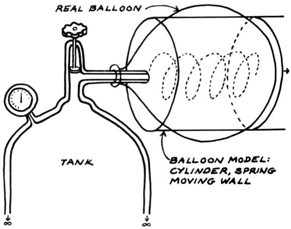

旧的图片非常复杂，因为气球膨胀的几何形状是三维的，而我不是数学家，我是工程师。如果我转换到新图片，我可以清楚地看到气球的弹性集中到可以膨胀和收缩的弹簧中，并且我可以看到膨胀的体积方面是质量很小的可移动气球皮壁，仅在一个方向移动方向。如果简化方法的方程与真实气球的方程相似，我可以用简化的一维方程预测真实气球的行为。这就是他们所说的模型的意思。

The old picture is intractably complex because the geometry of the balloon's expanding is three-dimensional and I'm not a mathematician, I'm an engineer. If I convert to the new picture, I can clearly see the stretchiness of the balloon lumped into a spring that can expand and contract, and I can see the expanded volume aspect as a movable balloon skin wall with very little mass, moving in only one direction. If the equations for the simplified approach are similar to the equations for the real balloon, I can predict the behavior of the real balloon with my simplified, one-dimensional equations. This is what they mean by a model.

步骤 4. 重新绘制新图片，显示气球皮肤的运动。

Step 4. Redraw new picture, showing the motion of the balloon skin.

当空气从储气罐进入气球时，气球皮会移动 (A2) 并且弹簧会拉伸。现在要记住这个问题。找出气球体积如何随时间变化。假想的一维圆柱形气球的体积恰好是其长度乘以其圆形可移动蒙皮的恒定面积。问题归结为找出气球长度如何随时间变化。我正在进步。

As air enters the balloon from the tank, the balloon skin moves (A2) and the spring stretches. Now to remember the problem. Find how the balloon volume varies with time. The volume of the imaginary, one-dimensional cylindrical balloon is just its length times the constant area of its circular movable skin. The problem reduces to finding how the balloon length varies with time. I'm making progress.

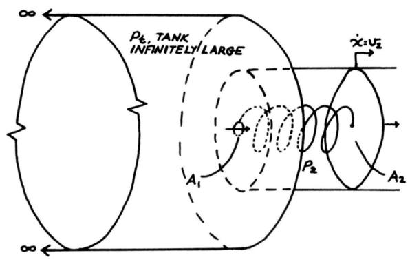

2月27日

February 27

海伍德教授的内燃机课在 38 号楼三楼的另一个带调光器的室内房间里进行。

Professor Heywood's Internal Combustion Engine class was on the third floor of Building 38, in another interior room with dimmers.

海伍德喜欢讲义和幻灯片的授课方式。他分发了屏幕上内容的副本，并指着图表并用不同颜色的笔在透明胶片上做了笔记。这对他和我们来说都很有效。我们不会浪费时间试图重画他更容易复印的东西，海伍德教授也不会在他的米色灯芯绒夹克上沾上粉笔灰。

Heywood favored the handouts and slides approach to lecturing. He distributed copies of what would be on the screen and pointed to the diagram and made notes on the transparencies with different colored pens. This was efficient both for him and for us. We would not waste time trying to redraw what would be easier for him to photocopy, and Professor Heywood would not get chalk dust on his beige corduroy jacket.

海伍德身材修长，看起来比四十五岁还要年轻。也许每天骑自行车往返他在牛顿的家有帮助。他是众多在石油和汽车公司资助下骑自行车上班的机械工程教授之一——他重视效率。

Heywood was trim and looked younger than his forty-five years. Maybe the bicycle ride to and from his house in Newton every day helped. He was one of the many mechanical engineering professors who cycled to work even though funded by oil and car companies-he valued efficiency.

他很年轻就获得了终身教职，尽管他比大多数教员都聪明，但他并没有创办过一家公司。他更喜欢写书，在需要时进行咨询，成为一名杰出的学者。有一天，我看到他一边吃午饭，一边望着基利安庭院的树林，也许是在想，麻省理工学院的环境不如剑桥或伦敦帝国理工学院那么宜人，但这里的工资和税收都更好，而且美国的汽车工业还没有消亡。也许有一天，斯隆实验室将成为海伍德实验室，而实验室将以英国方式发音。